# TP 2 marked abundance

Olivier Gimenez

19/12/2020

On charge le package `RMark`.

```r
library(RMark)
```

Et aussi le tidyverse.

```r
library(tidyverse)
```

# Partie 1 : le cours

Les données.

```r
capsid <- convert.inp("dat/capsid.inp",
                    group.df = NULL,
                    covariates = NULL)
head(capsid)
```

```
##              ch freq
## 1 0000000000001   47
## 2 0000000000010   36
## 3 0000000000011   12
## 4 0000000000100   30
## 5 0000000000101    8
## 6 0000000000110    1
```

```r
tail(capsid)
```

```
##                ch freq
## 244 1100000000000    4
## 245 1100000000000   -1
## 248 1100100100000    1
## 250 1110000000000    1
## 251 1110001000000    1
## 252 1111000000000    2
```

On charge le package `secr` qui permet d’implémenter le test de `closure`.

```r
library(secr)
```

On met les données au format adéquat.

```r
capsid_secr <- unRMarkInput(capsid)
```

On explore le jeu de données.

```r
summary(capsid_secr)
```

```
## Object class       capthist
##
## Counts by occasion
##              1   2   3   4   5   6   7   8    9   10   11   12   13 Total
## n           54 144 166 203 186 197 231 164  161  122  118  118  142  2006
## u           54 134 127 147 132 131 134  89   60   42   44   48   47  1189
## f          690 295 123  62  13   3   0   1    2    0    0    0    0  1189
## M(t+1)      54 188 315 462 594 725 859 948 1008 1050 1094 1142 1189  1189
## losses       0   1   0   1   1   1   1   0    1    0    1    0    0     7
## detections  54 144 166 203 186 197 231 164  161  122  118  118  142  2006
```

On fait les tests de Stanley et Burnham et de Otis.

```r
test <- closure.test(capsid_secr, SB = TRUE)
```

Pour Otis, on a :

```r
test$Otis
```

```
##  statistic            p
##  -7.419844 5.862897e-14
```

Pour Stanley-Burnham, on a :

```r
test$Xc
```

```
##  statistic df p
##   682.1555 22 0
```

Les composantes de Stanley-Burnham :

```r
test$NRvsJS
```

```
##  statistic df p
##   264.6914 11 0
```

```r
test$MtvsNM
```

```
##  statistic df         p
##   11.07903 11 0.4366662
```

```r
test$MtvsNR
```

```
##  statistic df p
##   417.4641 11 0
```

```r
test$NRvsJS
```

```
##  statistic df p
##   264.6914 11 0
```

Les sous-composantes de NR vs JS.

```r
round(test$compNRvsJS, 2)
```

```
##    Occasion Chisquare df    p
## 1         2     19.26  1 0.00
## 2         3     53.24  1 0.00
## 3         4     50.12  1 0.00
## 4         5     27.88  1 0.00
## 5         6     22.70  1 0.00
## 6         7     30.18  1 0.00
## 7         8      8.24  1 0.00
## 8         9     25.47  1 0.00
## 9        10     18.55  1 0.00
## 10       11      8.17  1 0.00
## 11       12      0.88  1 0.35
```

Les sous-composantes de NM vs JS.

```r
round(test$compNMvsJS, 2)
```

```
##    Occasion Chisquare df    p
## 1         2      8.77  1 0.00
## 2         3      0.59  1 0.44
## 3         4      2.42  1 0.12
## 4         5     22.65  1 0.00
## 5         6     57.85  1 0.00
## 6         7     82.95  1 0.00
## 7         8    143.12  1 0.00
## 8         9     78.76  1 0.00
## 9        10    101.06  1 0.00
## 10       11     84.54  1 0.00
## 11       12     88.37  1 0.00
```

On supprime les 3 premières et dernières occasions. On sépare d’abord les colonnes, on sélectionne les colonnes 4 à 10, on supprime les lignes de 0, puis on les recolle et on reconvertit au format requis.

```r
capsid_reduced <- capsid
ch <- splitCH(capsid_reduced$ch) # sépare colonnes
head(ch)
```

```
##      Time1 Time2 Time3 Time4 Time5 Time6 Time7 Time8 Time9 Time10 Time11 Time12
## [1,]     0     0     0     0     0     0     0     0     0      0      0      0
## [2,]     0     0     0     0     0     0     0     0     0      0      0      1
## [3,]     0     0     0     0     0     0     0     0     0      0      0      1
## [4,]     0     0     0     0     0     0     0     0     0      0      1      0
## [5,]     0     0     0     0     0     0     0     0     0      0      1      0
## [6,]     0     0     0     0     0     0     0     0     0      0      1      1
##      Time13
## [1,]      1
## [2,]      0
## [3,]      1
## [4,]      0
## [5,]      1
## [6,]      0
```

```r
ch_reduced <- ch[, 4:10] # sélection colonnes 4 à 10
head(ch_reduced)
```

```
##      Time4 Time5 Time6 Time7 Time8 Time9 Time10
## [1,]     0     0     0     0     0     0      0
## [2,]     0     0     0     0     0     0      0
## [3,]     0     0     0     0     0     0      0
## [4,]     0     0     0     0     0     0      0
## [5,]     0     0     0     0     0     0      0
## [6,]     0     0     0     0     0     0      0
```

```r
dim(ch_reduced)
```

```
## [1] 231   7
```

```r
mask <- apply(ch_reduced, 1, sum)
ch_reduced <- ch_reduced[mask > 0,] # supprime lignes de 0
head(ch_reduced)
```

```
##      Time4 Time5 Time6 Time7 Time8 Time9 Time10
## [1,]     0     0     0     0     0     0      1
## [2,]     0     0     0     0     0     0      1
## [3,]     0     0     0     0     0     0      1
## [4,]     0     0     0     0     0     0      1
## [5,]     0     0     0     0     0     0      1
## [6,]     0     0     0     0     0     0      1
```

```r
dim(ch_reduced)
```

```
## [1] 206   7
```

```r
freq_reduced <- capsid_reduced$freq[mask > 0]
length(freq_reduced)
```

```
## [1] 206
```

```r
capsid_reduced <- data.frame(ch = collapseCH(ch_reduced), # on recolle les colonnes ensemble
                             freq = freq_reduced)
capsid_reduced_secr <- unRMarkInput(capsid_reduced) # on convertit au bon format
```

Jette un coup d’oeil.

```r
summary(capsid_reduced_secr)
```

```
## Object class       capthist
##
## Counts by occasion
##              1   2   3   4   5   6   7 Total
## n          203 186 197 231 164 161 122  1264
## u          203 156 145 147  93  66  43   853
## f          559 204  68  18   3   1   0   853
## M(t+1)     203 359 504 651 744 810 853   853
## losses       1   1   1   1   0   1   0     5
## detections 203 186 197 231 164 161 122  1264
```

On refait les tests de Stanley et Burnham et de Otis.

```r
closure.test(capsid_reduced_secr, SB = TRUE)
```

```
## $Otis
##  statistic            p
##  -3.408934 0.0003260862
##
## $Xc
##  statistic df p
##   212.0965 10 0
##
## $NRvsJS
##  statistic df            p
##   46.69577  5 6.553423e-09
##
## $NMvsJS
##  statistic df p
##   208.4222  5 0
##
## $MtvsNR
##  statistic df p
##   165.4008  5 0
##
## $MtvsNM
##  statistic df         p
##   3.674328  5 0.5971889
##
## $compNRvsJS
##   Occasion  Chisquare df            p
## 1        2 14.3423440  1 0.0001523982
## 2        3 14.7847588  1 0.0001205055
## 3        4 14.5324748  1 0.0001377642
## 4        5  0.9609364  1 0.3269510743
## 5        6  2.0752608  1 0.1497043444
##
## $compNMvsJS
##   Occasion Chisquare df            p
## 1        2  12.92835  1 3.236426e-04
## 2        3  34.03060  1 5.425200e-09
## 3        4  51.93692  1 5.731251e-13
## 4        5  81.58510  1 1.678748e-19
## 5        6  27.94123  1 1.250563e-07
```

Ca change pas grand chose. Est-ce le bon fichier capsid.inp?!

# Partie 2 : mouse deer

Les données

```r
mouse <- convert.inp("dat/deer-mouse-nogroup.inp",
                    group.df = NULL,
                    covariates = NULL)
head(mouse)
```

```
##       ch freq
## 1 111111    1
## 2 100111    1
## 3 110011    1
## 4 110111    1
## 5 111111    1
## 6 110111    1
```

```r
tail(mouse)
```

```
##        ch freq
## 33 000010    1
## 34 000010    1
## 35 000010    1
## 36 000001    1
## 37 000001    1
## 38 000001    1
```

On fait les tests de fermeture.

```r
mouse_secr <- unRMarkInput(mouse) # on convertit au bon format
summary(mouse_secr) # resumes
```

```
## Object class       capthist
##
## Counts by occasion
##             1  2  3  4  5  6 Total
## n          15 20 16 19 25 25   120
## u          15  8  6  3  3  3    38
## f           9  6  7  6  6  4    38
## M(t+1)     15 23 29 32 35 38    38
## losses      0  0  0  0  0  0     0
## detections 15 20 16 19 25 25   120
```

```r
closure.test(mouse_secr, SB = TRUE)
```

```
## $Otis
##  statistic         p
##  0.7649179 0.7778398
##
## $Xc
##  statistic df         p
##     11.668  7 0.1120193
##
## $NRvsJS
##  statistic df          p
##    9.31129  3 0.02542603
##
## $NMvsJS
##   statistic df         p
##  0.04895105  1 0.8248987
##
## $MtvsNR
##  statistic df        p
##   2.356705  4 0.670465
##
## $MtvsNM
##  statistic df          p
##   11.61904  6 0.07102745
##
## $compNRvsJS
##   Occasion  Chisquare df           p
## 1        2 7.44579710  1 0.006358475
## 2        3 0.04505929  1 0.831895047
## 3        4 1.82043344  1 0.177261692
## 4        5         NA NA          NA
##
## $compNMvsJS
##   Occasion  Chisquare df         p
## 1        2         NA NA        NA
## 2        3         NA NA        NA
## 3        4         NA NA        NA
## 4        5 0.04895105  1 0.8248987
```

Process data

```r
mouse.proc <- process.data(mouse, begin.time = 1, model = "FullHet")
```

Create default design data

```r
mouse.ddl <- make.design.data(mouse.proc)
```

Here, we set up the structures for ‘p’ and ‘c’. I use the “share = TRUE” or “share = FALSE” options in each of the structures to indicate whether ‘p’ & ‘c’ should share the same columns of the design matrix or not. Although this is not necessary for all of the structures below, it does add a covariate “c” to the design data with c=0 for rows pertaining to parameter ‘p’ and c=1 for rows pertaining to parameter ’c. This is nice as it gives us the opportunity to build some of the additive structures we’re interested in. We can then use the covariate “c” in formula statements if we want to. But, we don’t have to include that covariate if we don’t want to (e.g., see the p.dot structure).

```r
run.mouse <- function() {

  p.dot <- list(formula =  ~ 1, share = TRUE)
  p.dot.behav <- list(formula =  ~ 1, share = FALSE)
  p.time <- list(formula =  ~ time, share = TRUE)
  p.time.behav <- list(formula =  ~ time, share = FALSE)
  p.h <- list(formula = ~ mixture, share = TRUE)
  p.h.behav <- list(formula = ~ mixture, share = FALSE)
  p.h.time <- list(formula = ~ time + mixture, share = TRUE)
  p.h.time.behav <- list(formula = ~ time + mixture, share = FALSE)

  mouse.model.list <- create.model.list("FullHet")

  mouse.results <- mark.wrapper(mouse.model.list,
                              data = mouse.proc,
                              ddl = mouse.ddl)

  return(mouse.results)
}
```

Run the models and examine the output

```r
mouse.results <- run.mouse()
```

```
##
## Output summary for FullHet model
## Name : pi(~1)p(~1)c()f0(~1)
##
## Npar :  3
## -2lnL:  109.5069
## AICc :  115.614
##
## Beta
##                     estimate           se           lcl          ucl
## pi:(Intercept)  2.462556e-04 3.548114e+03 -6.954302e+03 6.954303e+03
## p:(Intercept)   1.053605e-01 1.326371e-01 -1.546082e-01 3.653292e-01
## f0:(Intercept) -2.499948e+01 1.152830e+04 -2.262047e+04 2.257047e+04
##
##
## Real Parameter pi
##
##
## mixture:1 0.5000616
##
##
## Real Parameter p
##
##                   1         2         3         4         5         6
## mixture:1 0.5263158 0.5263158 0.5263158 0.5263158 0.5263158 0.5263158
## mixture:2 0.5263158 0.5263158 0.5263158 0.5263158 0.5263158 0.5263158
##
##
## Real Parameter c
##
##                   2         3         4         5         6
## mixture:1 0.5263158 0.5263158 0.5263158 0.5263158 0.5263158
## mixture:2 0.5263158 0.5263158 0.5263158 0.5263158 0.5263158
##
##
## Real Parameter f0
##
##            1
##  1.38952e-11
##
```

[output cut: 288 more lines]

```
## mixture:1 0.3947369 0.347826 0.3999999 0.3333334 0.4999999 1
## mixture:2 0.3947369 0.347826 0.3999999 0.3333334 0.4999999 1
##
##
## Real Parameter c
##
##                   2         3         4         5         6
## mixture:1 0.6119403 0.6119403 0.6119403 0.6119403 0.6119403
## mixture:2 0.6119403 0.6119403 0.6119403 0.6119403 0.6119403
##
##
## Real Parameter f0
##
##             1
##  1.048184e-12
```

Examine model-selection table

```r
mouse.results
```

```
##                                 model npar      AICc DeltaAICc weight Deviance
## 1                pi(~1)p(~1)c()f0(~1)    3 115.61399        NA     NA 85.44111
## 2              pi(~1)p(~1)c(~1)f0(~1)    4 106.16685        NA     NA 73.92174
## 3          pi(~1)p(~mixture)c()f0(~1)    4        NA        NA     NA  2.00000
## 4        pi(~1)p(~mixture)c(~1)f0(~1)    5 108.25775        NA     NA 73.92174
## 5   pi(~1)p(~time + mixture)c()f0(~1)    9  99.58481        NA     NA 56.69338
## 6 pi(~1)p(~time + mixture)c(~1)f0(~1)   10 114.73503        NA     NA 69.65547
## 7             pi(~1)p(~time)c()f0(~1)    8 116.33249        NA     NA 75.60922
## 8           pi(~1)p(~time)c(~1)f0(~1)    9 112.54690        NA     NA 69.65547
```

examine model names and find the name of the top model

```r
names(mouse.results)
```

```
## [1] "p.dot"          "p.dot.behav"    "p.h"            "p.h.behav"
## [5] "p.h.time"       "p.h.time.behav" "p.time"         "p.time.behav"
## [9] "model.table"
```

examine the output from top-ranked model (#5)

```r
mouse.results$p.h.time$results$real
```

```
##              estimate        se       lcl        ucl fixed note
## pi g1 m1    0.4253669 0.1403005 0.1937537  0.6951362
## p g1 t1 m1  0.6526771 0.1291144 0.3809498  0.8515960
## p g1 t2 m1  0.7878771 0.0986041 0.5388675  0.9219087
## p g1 t3 m1  0.6837150 0.1242590 0.4120879  0.8695669
## p g1 t4 m1  0.7647741 0.1055892 0.5071525  0.9112875
## p g1 t5 m1  0.8778169 0.0646522 0.6879265  0.9590422
## p g1 t6 m1  0.8778170 0.0646522 0.6879265  0.9590422
## p g1 t1 m2  0.1657046 0.0819023 0.0585491  0.3881237
## p g1 t2 m2  0.2819049 0.1169989 0.1122629  0.5492815
## p g1 t3 m2  0.1859853 0.0893261 0.0670600  0.4207077
## p g1 t4 m2  0.2557505 0.1106263 0.0990951  0.5177356
## p g1 t5 m2  0.4316087 0.1396369 0.1992614  0.6985358
## p g1 t6 m2  0.4316087 0.1396369 0.1992615  0.6985359
## f0 g1 a0 t1 2.2310267 2.6918398 0.3480740 14.3000620
```

```r
mouse.results$p.h.time$results$derived
```

```
## $`N Population Size`
##   estimate      lcl      ucl
## 1 40.23103 38.34807 52.30006
```

Comme dans les diapos.

```r
mouse.results$p.dot.behav$results$real
```

```
##              estimate        se       lcl        ucl fixed note
## pi g1 m1    0.5000003 0.0000000 0.5000003  0.5000003
## p g1 t1 m1  0.3424124 0.0727433 0.2165697  0.4951615
## c g1 t2 m1  0.6119403 0.0420970 0.5269787  0.6906012
## f0 g1 a0 t1 2.8295485 3.0854498 0.4991967 16.0384580
```

```r
mouse.results$p.dot.behav$results$derived
```

```
## $`N Population Size`
##   estimate     lcl      ucl
## 1 40.82955 38.4992 54.03846
```

La même chose avec le sexe maintenant.

Les données

```r
mouse <- convert.inp("dat/deer-mouse-sex2G-MF.inp",
                    group.df = data.frame(sex = c("M","F")),
                    covariates = NULL)
head(mouse)
```

```
##         ch freq sex
## 1:1 111111    1   M
## 1:3 110011    1   M
## 1:4 110111    1   M
## 1:5 111111    1   M
## 1:6 110111    1   M
## 1:7 111110    1   M
```

```r
tail(mouse)
```

```
##          ch freq sex
## 2:28 001010    1   F
## 2:29 001000    1   F
## 2:30 000100    1   F
## 2:32 000110    1   F
## 2:34 000010    1   F
## 2:38 000001    1   F
```

On sépare mâles et femelles.

```r
mouseM <- mouse[mouse$sex == "M", ]
mouseF <- mouse[mouse$sex == "F", ]
```

On formate les données.

```r
mouseM_secr <- unRMarkInput(mouseM) # on convertit au bon format
mouseF_secr <- unRMarkInput(mouseF) # on convertit au bon format
summary(mouseM_secr) # resumes
```

```
## Object class       capthist
##
## Counts by occasion
##             1  2  3  4  5  6 Total
## n          12 15  8 12 16 16    79
## u          12  4  0  1  2  2    21
## f           4  1  4  3  5  4    21
## M(t+1)     12 16 16 17 19 21    21
## losses      0  0  0  0  0  0     0
## detections 12 15  8 12 16 16    79
##
## Individual covariates
##  sex
##  M:21
```

```r
summary(mouseF_secr) # resumes
```

```
## Object class       capthist
##
## Counts by occasion
##            1 2  3  4  5  6 Total
## n          3 5  8  7  9  9    41
## u          3 4  6  2  1  1    17
## f          5 5  3  3  1  0    17
## M(t+1)     3 7 13 15 16 17    17
## losses     0 0  0  0  0  0     0
## detections 3 5  8  7  9  9    41
##
## Individual covariates
##  sex
##  F:17
```

On fait les tests de fermeture, mâles d’abord.

```r
closure.test(mouseM_secr, SB = TRUE)
```

```
## $Otis
##  statistic        p
##   1.408787 0.920551
##
## $Xc
##  statistic df          p
##   11.31081  6 0.07923259
##
## $NRvsJS
##  statistic df           p
##   9.316319  2 0.009483899
##
## $NMvsJS
##  statistic df p
##          0  0 1
##
## $MtvsNR
##  statistic df         p
##   1.994488  4 0.7367727
##
## $MtvsNM
##  statistic df          p
##   11.31081  6 0.07923259
##
## $compNRvsJS
##   Occasion Chisquare df          p
## 1        2  5.619444  1 0.01776228
## 2        3        NA NA         NA
## 3        4  3.696875  1 0.05451448
## 4        5        NA NA         NA
##
## $compNMvsJS
##   Occasion Chisquare df  p
## 1        2        NA NA NA
## 2        3        NA NA NA
## 3        4        NA NA NA
## 4        5        NA NA NA
```

Femelles ensuite

```r
closure.test(mouseF_secr, SB = TRUE)
```

```
## $Otis
##  statistic         p
##  0.2255718 0.5892328
##
## $Xc
##  statistic df         p
##   3.362287  5 0.6443199
##
## $NRvsJS
##  statistic df         p
##    1.63254  1 0.2013521
##
## $NMvsJS
##  statistic df         p
##  0.2539683  1 0.6142947
##
## $MtvsNR
##  statistic df         p
##   1.729747  4 0.7853071
##
## $MtvsNM
##  statistic df        p
##   3.108319  4 0.539865
##
## $compNRvsJS
##   Occasion Chisquare df         p
## 1        2        NA NA        NA
## 2        3   1.63254  1 0.2013521
## 3        4        NA NA        NA
## 4        5        NA NA        NA
##
## $compNMvsJS
##   Occasion Chisquare df         p
## 1        2        NA NA        NA
## 2        3        NA NA        NA
## 3        4        NA NA        NA
## 4        5 0.2539683  1 0.6142947
```

Les modèles maintenant.

Process data

```r
mouse.proc <- process.data(mouse, begin.time = 1, model = "FullHet", groups = "sex")
```

Create default design data

```r
mouse.ddl <- make.design.data(mouse.proc)
```

Liste des modèles.

```r
run.mouse <- function() {

  p.dot <- list(formula =  ~ 1, share = TRUE)
  p.dot.behav <- list(formula =  ~ 1, share = FALSE)
  p.time <- list(formula =  ~ time, share = TRUE)
  p.time.behav <- list(formula =  ~ time, share = FALSE)
  p.h <- list(formula = ~ mixture, share = TRUE)
  p.h.behav <- list(formula = ~ mixture, share = FALSE)
  p.h.time <- list(formula = ~ time + mixture, share = TRUE)
  p.h.time.behav <- list(formula = ~ time + mixture, share = FALSE)
  p.sex <- list(formula =  ~ sex, share = TRUE)
  p.sex.behav <- list(formula =  ~ sex, share = FALSE)
  p.time.sex <- list(formula =  ~ time + sex, share = TRUE)
  p.time.behav.sex <- list(formula =  ~ time + sex, share = FALSE)
  p.h.sex <- list(formula = ~ mixture + sex, share = TRUE)
  p.h.behav.sex <- list(formula = ~ mixture + sex, share = FALSE)
  p.h.time.sex <- list(formula = ~ time + mixture + sex, share = TRUE)
  p.h.time.behav.sex <- list(formula = ~ time + mixture + sex, share = FALSE)

  mouse.model.list <- create.model.list("FullHet")

  mouse.results <- mark.wrapper(mouse.model.list,
                              data = mouse.proc,
                              ddl = mouse.ddl)

  return(mouse.results)
}
```

Run the models and examine the output

```r
mouse.results <- run.mouse()
```

```
##
## Output summary for FullHet model
## Name : pi(~1)p(~1)c()f0(~1)
##
## Npar :  3
## -2lnL:  157.6728
## AICc :  163.78
##
## Beta
##                     estimate           se           lcl          ucl
## pi:(Intercept)  4.082034e-05 1820.8594000 -3.568884e+03 3.568885e+03
## p:(Intercept)   1.053605e-01    0.1326371 -1.546082e-01 3.653292e-01
## f0:(Intercept) -1.801162e+01 5218.5702000 -1.024641e+04 1.021039e+04
##
##
## Real Parameter pi
## Group:sexF
##
## mixture:1 0.5000102
##
## Group:sexM
##
## mixture:1 0.5000102
##
##
## Real Parameter p
## Group:sexF
##                   1         2         3         4         5         6
## mixture:1 0.5263158 0.5263158 0.5263158 0.5263158 0.5263158 0.5263158
## mixture:2 0.5263158 0.5263158 0.5263158 0.5263158 0.5263158 0.5263158
##
## Group:sexM
##                   1         2         3         4         5         6
## mixture:1 0.5263158 0.5263158 0.5263158 0.5263158 0.5263158 0.5263158
## mixture:2 0.5263158 0.5263158 0.5263158 0.5263158 0.5263158 0.5263158
##
##
## Real Parameter c
## Group:sexF
##                   2         3         4         5         6
```

[output cut: 921 more lines]

```
##
## Group:sexM
##                   2         3         4         5         6
## mixture:1 0.6317382 0.5228744 0.6054401 0.7538494 0.7538494
## mixture:2 0.6317382 0.5228744 0.6054401 0.7538494 0.7538494
##
##
## Real Parameter f0
## Group:sexF
##            1
##  4.23878e-14
##
## Group:sexM
##            1
##  4.23878e-14
```

Examine model-selection table

```r
mouse.results
```

```
##                                        model npar     AICc  DeltaAICc
## 10   pi(~1)p(~time + mixture + sex)c()f0(~1)   10 146.3169  0.0000000
## 6           pi(~1)p(~mixture + sex)c()f0(~1)    5 147.2589  0.9420054
## 7          pi(~1)p(~time + mixture)c()f0(~1)    9 148.9379  2.6209832
## 3                 pi(~1)p(~mixture)c()f0(~1)    4 150.4044  4.0874273
## 11                    pi(~1)p(~sex)c()f0(~1)    4 154.3203  8.0033573
## 16             pi(~1)p(~time + sex)c()f0(~1)    9 154.5961  8.2792232
## 2                     pi(~1)p(~1)c(~1)f0(~1)    4 155.7349  9.4179473
## 12                  pi(~1)p(~sex)c(~1)f0(~1)    5 156.8823 10.5653954
## 4               pi(~1)p(~mixture)c(~1)f0(~1)    5 157.8258 11.5088454
## 5         pi(~1)p(~mixture + sex)c(~1)f0(~1)    6 158.9921 12.6752156
## 14                 pi(~1)p(~time)c(~1)f0(~1)    9 160.7129 14.3959432
## 15           pi(~1)p(~time + sex)c(~1)f0(~1)   10 162.1850 15.8680800
## 8        pi(~1)p(~time + mixture)c(~1)f0(~1)   10 162.9010 16.5840800
## 1                       pi(~1)p(~1)c()f0(~1)    3 163.7800 17.4630380
```

[output cut: 19 more lines]

examine model names and find the name of the top model

```r
names(mouse.results)
```

```
##  [1] "p.dot"              "p.dot.behav"        "p.h"
##  [4] "p.h.behav"          "p.h.behav.sex"      "p.h.sex"
##  [7] "p.h.time"           "p.h.time.behav"     "p.h.time.behav.sex"
## [10] "p.h.time.sex"       "p.sex"              "p.sex.behav"
## [13] "p.time"             "p.time.behav"       "p.time.behav.sex"
## [16] "p.time.sex"         "model.table"
```

examine the output from top-ranked model (#10)

```r
mouse.results$p.h.time.sex$results$real
```

```
##              estimate        se          lcl        ucl fixed note
## pi gF m1    0.7018782 0.1396728 0.3888716000  0.8970228
## p gF t1 m1  0.3019266 0.1420173 0.1035107000  0.6183453
## p gF t2 m1  0.4523813 0.1678804 0.1795670000  0.7571608
## p gF t3 m1  0.3304236 0.1489006 0.1165637000  0.6485887
## p gF t4 m1  0.4209035 0.1645755 0.1621312000  0.7319080
## p gF t5 m1  0.6136197 0.1683892 0.2830260000  0.8646672
## p gF t6 m1  0.6136197 0.1683892 0.2830260000  0.8646671
## p gF t1 m2  0.0325286 0.0769576 0.0002785795  0.8022467
## p gF t2 m2  0.0603425 0.1390161 0.0005253776  0.8869450
## p gF t3 m2  0.0369445 0.0870318 0.0003173820  0.8225465
## p gF t4 m2  0.0534796 0.1240033 0.0004641095  0.8730216
## p gF t5 m2  0.1098893 0.2423384 0.0009597527  0.9407064
## p gF t6 m2  0.1098893 0.2423384 0.0009597525  0.9407064
## p gM t1 m1  0.6307607 0.1111774 0.4012789000  0.8132249
## p gM t2 m1  0.7654093 0.0891799 0.5520871000  0.8962309
## p gM t3 m1  0.6609101 0.1075823 0.4320384000  0.8331675
## p gM t4 m1  0.7416489 0.0942106 0.5226956000  0.8827018
## p gM t5 m1  0.8624958 0.0632740 0.6879329000  0.9469433
## p gM t6 m1  0.8624957 0.0632740 0.6879328000  0.9469433
## p gM t1 m2  0.1172282 0.2214273 0.0019997000  0.8979677
## p gM t2 m2  0.2023199 0.3469964 0.0037358000  0.9449207
## p gM t3 m2  0.1315785 0.2446854 0.0022735000  0.9097034
## p gM t4 m2  0.1824450 0.3203077 0.0033056000  0.9375607
## p gM t5 m2  0.3277784 0.4798639 0.0067811000  0.9720858
## p gM t6 m2  0.3277784 0.4798639 0.0067811000  0.9720858
## f0 gF a0 t1 2.0450571 5.2560052 0.1253856000 33.3551710
```

```r
mouse.results$p.h.time.sex$results$derived
```

```
## $`N Population Size`
##   estimate      lcl      ucl
## 1 19.04506 17.12539 50.35517
## 2 23.04506 21.12539 54.35517
```

Comme dans les diapos.

```r
mouse.results$p.dot.behav$results$real
```

```
##              estimate        se       lcl       ucl fixed note
## pi gF m1    0.4999984 0.0000000 0.4999984 0.4999984
## p gF t1 m1  0.3697890 0.0723413 0.2420376 0.5188152
## c gF t2 m1  0.6119403 0.0420970 0.5269786 0.6906012
## f0 gF a0 t1 0.7301105 1.2610685 0.0728901 7.3132226
```

```r
mouse.results$p.dot.behav$results$derived
```

```
## $`N Population Size`
##   estimate      lcl      ucl
## 1 17.73011 17.07289 24.31322
## 2 21.73011 21.07289 28.31322
```

La même chose avec l’âge maintenant.

Les données

```r
mouse <- convert.inp("dat/deer-mouse-age-3G-Y-SA-A.inp",
                    group.df = data.frame(ages = c("Y","SA", "A")),
                    covariates = NULL)
head(mouse)
```

```
##         ch freq ages
## 1:1 111111    1    Y
## 1:2 100111    1    Y
## 1:3 110011    1    Y
## 1:4 110111    1    Y
## 1:5 111111    1    Y
## 1:7 111110    1    Y
```

```r
tail(mouse)
```

```
##          ch freq ages
## 3:25 001111    1    A
## 3:28 001010    1    A
## 3:29 001000    1    A
## 3:30 000100    1    A
## 3:35 000010    1    A
## 3:38 000001    1    A
```

```r
mouseY <- mouse[mouse$ages == "Y", ]
mouseSA <- mouse[mouse$ages == "SA", ]
mouseA <- mouse[mouse$ages == "A", ]
```

On formate les données.

```r
mouseY_secr <- unRMarkInput(mouseY) # on convertit au bon format
mouseSA_secr <- unRMarkInput(mouseSA) # on convertit au bon format
mouseA_secr <- unRMarkInput(mouseA) # on convertit au bon format
```

On fait les tests de fermeture, Y d’abord.

```r
closure.test(mouseY_secr, SB = TRUE)
```

```
## $Otis
##  statistic         p
##  0.5894871 0.7222327
##
## $Xc
##  statistic df         p
##   4.215069  6 0.6475973
##
## $NRvsJS
##  statistic df       p
##   2.778116  2 0.24931
##
## $NMvsJS
##  statistic df p
##          0  0 1
##
## $MtvsNR
##  statistic df         p
##   1.436953  4 0.8377477
##
## $MtvsNM
##  statistic df         p
##   4.215069  6 0.6475973
##
## $compNRvsJS
##   Occasion  Chisquare df          p
## 1        2 2.74285714  1 0.09768996
## 2        3 0.03525886  1 0.85105427
## 3        4         NA NA         NA
## 4        5         NA NA         NA
##
## $compNMvsJS
##   Occasion Chisquare df  p
## 1        2        NA NA NA
## 2        3        NA NA NA
## 3        4        NA NA NA
## 4        5        NA NA NA
```

SA ensuite.

```r
closure.test(mouseSA_secr, SB = TRUE)
```

```
## $Otis
##   statistic         p
##  -0.5516773 0.2905847
##
## $Xc
##    statistic df p
##  4.54041e-05  4 1
##
## $NRvsJS
##  statistic df p
##          0  0 1
##
## $NMvsJS
##  statistic df p
##          0  0 1
##
## $MtvsNR
##    statistic df p
##  4.54041e-05  4 1
##
## $MtvsNM
##    statistic df p
##  4.54041e-05  4 1
##
## $compNRvsJS
##   Occasion Chisquare df  p
## 1        2        NA NA NA
## 2        3        NA NA NA
## 3        4        NA NA NA
## 4        5        NA NA NA
##
## $compNMvsJS
##   Occasion Chisquare df  p
## 1        2        NA NA NA
## 2        3        NA NA NA
## 3        4        NA NA NA
## 4        5        NA NA NA
```

A enfin

```r
closure.test(mouseA_secr, SB = TRUE)
```

```
## $Otis
##  statistic         p
##  0.2004625 0.5794406
##
## $Xc
##  statistic df         p
##   1.247729  4 0.8701795
##
## $NRvsJS
##  statistic df p
##          0  0 1
##
## $NMvsJS
##  statistic df p
##          0  1 1
##
## $MtvsNR
##  statistic df         p
##   1.247729  4 0.8701795
##
## $MtvsNM
##  statistic df         p
##   1.247729  3 0.7415811
##
## $compNRvsJS
##   Occasion Chisquare df  p
## 1        2        NA NA NA
## 2        3        NA NA NA
## 3        4        NA NA NA
## 4        5        NA NA NA
##
## $compNMvsJS
##   Occasion Chisquare df  p
## 1        2        NA NA NA
## 2        3        NA NA NA
## 3        4        NA NA NA
## 4        5         0  1  1
```

Les modèles maintenant.

Process data

```r
mouse.proc <- process.data(mouse, begin.time = 1, model = "FullHet", groups = "ages")
```

Create default design data

```r
mouse.ddl <- make.design.data(mouse.proc)
```

Liste des modèles.

```r
run.mouse <- function() {

  p.dot <- list(formula =  ~ 1, share = TRUE)
  p.dot.behav <- list(formula =  ~ 1, share = FALSE)
  p.time <- list(formula =  ~ time, share = TRUE)
  p.time.behav <- list(formula =  ~ time, share = FALSE)
  p.h <- list(formula = ~ mixture, share = TRUE)
  p.h.behav <- list(formula = ~ mixture, share = FALSE)
  p.h.time <- list(formula = ~ time + mixture, share = TRUE)
  p.h.time.behav <- list(formula = ~ time + mixture, share = FALSE)
  p.age <- list(formula =  ~ ages, share = TRUE)
  p.age.behav <- list(formula =  ~ ages, share = FALSE)
  p.time.age <- list(formula =  ~ time + ages, share = TRUE)
  p.time.behav.age <- list(formula =  ~ time + ages, share = FALSE)
  p.h.age <- list(formula = ~ mixture + ages, share = TRUE)
  p.h.behav.age <- list(formula = ~ mixture + ages, share = FALSE)
  p.h.time.age <- list(formula = ~ time + mixture + ages, share = TRUE)
  p.h.time.behav.age <- list(formula = ~ time + mixture + ages, share = FALSE)

  mouse.model.list <- create.model.list("FullHet")

  mouse.results <- mark.wrapper(mouse.model.list,
                              data = mouse.proc,
                              ddl = mouse.ddl)

  return(mouse.results)
}
```

Run the models and examine the output

```r
mouse.results <- run.mouse()
```

```
##
## Output summary for FullHet model
## Name : pi(~1)p(~ages)c()f0(~1)
##
## Npar :  5  (unadjusted=3)
## -2lnL:  160.7806
## AICc :  171.0508  (unadjusted=166.88769)
##
## Beta
##                     estimate          se          lcl         ucl
## pi:(Intercept) -2.343211e-04 396.6864700 -777.5057300 777.5052600
## p:(Intercept)  -3.677248e-01   0.2503559   -0.8584223   0.1229727
## p:agesSA        1.445814e-01   0.5363564   -0.9066772   1.1958399
## p:agesY         7.328387e-01   0.3023109    0.1403092   1.3253681
## f0:(Intercept) -2.403486e+01   0.0000000  -24.0348610 -24.0348610
##
##
## Real Parameter pi
## Group:agesA
##
## mixture:1 0.4999414
##
## Group:agesSA
##
## mixture:1 0.4999414
##
## Group:agesY
##
## mixture:1 0.4999414
##
##
## Real Parameter p
## Group:agesA
##                   1         2         3         4         5         6
## mixture:1 0.4090909 0.4090909 0.4090909 0.4090909 0.4090909 0.4090909
## mixture:2 0.4090909 0.4090909 0.4090909 0.4090909 0.4090909 0.4090909
##
## Group:agesSA
##                   1         2         3         4         5         6
## mixture:1 0.4444445 0.4444445 0.4444445 0.4444445 0.4444445 0.4444445
```

[output cut: 1217 more lines]

```
## mixture:2 0.6119402 0.6119402 0.6119402 0.6119402 0.6119402
##
##
## Real Parameter f0
## Group:agesA
##             1
##  2.213985e-10
##
## Group:agesSA
##             1
##  2.213985e-10
##
## Group:agesY
##             1
##  2.213985e-10
```

Examine model-selection table

```r
mouse.results
```

```
##                                         model npar     AICc  DeltaAICc
## 9           pi(~1)p(~time + mixture)c()f0(~1)    9 158.8302  0.0000000
## 10   pi(~1)p(~time + mixture + ages)c()f0(~1)   11 159.7338  0.9036041
## 5                  pi(~1)p(~mixture)c()f0(~1)    4 160.4039  1.5737241
## 6           pi(~1)p(~mixture + ages)c()f0(~1)    6 161.1978  2.3676324
## 4                      pi(~1)p(~1)c(~1)f0(~1)    4 165.8550  7.0248341
## 2                   pi(~1)p(~ages)c(~1)f0(~1)    6 167.7312  8.9009924
## 7                pi(~1)p(~mixture)c(~1)f0(~1)    5 167.9459  9.1157322
## 8         pi(~1)p(~mixture + ages)c(~1)f0(~1)    7 169.8602 11.0299928
## 15                  pi(~1)p(~time)c(~1)f0(~1)    9 170.3257 11.4955100
## 1                     pi(~1)p(~ages)c()f0(~1)    5 171.0508 12.2206322
## 16           pi(~1)p(~time + ages)c(~1)f0(~1)   11 171.3925 12.5623041
## 14             pi(~1)p(~time + ages)c()f0(~1)   10 171.6642 12.8340268
## 12 pi(~1)p(~time + mixture + ages)c(~1)f0(~1)   12 171.8714 13.0411847
## 11        pi(~1)p(~time + mixture)c(~1)f0(~1)   10 172.5138 13.6836468
```

[output cut: 19 more lines]

examine model names and find the name of the top model

```r
names(mouse.results)
```

```
##  [1] "p.age"              "p.age.behav"        "p.dot"
##  [4] "p.dot.behav"        "p.h"                "p.h.age"
##  [7] "p.h.behav"          "p.h.behav.age"      "p.h.time"
## [10] "p.h.time.age"       "p.h.time.behav"     "p.h.time.behav.age"
## [13] "p.time"             "p.time.age"         "p.time.behav"
## [16] "p.time.behav.age"   "model.table"
```

```r
mouse.results$p.h.time$results$real
```

```
##                   estimate           se          lcl          ucl fixed note
## pi gA aA m1   3.832800e-01 0.1410590000 1.617465e-01 0.6668543000
## p gA aA t1 m1 6.935520e-01 0.1261441000 4.142291e-01 0.8786882000
## p gA aA t2 m1 8.184006e-01 0.0905451000 5.772389e-01 0.9370059000
## p gA aA t3 m1 7.228762e-01 0.1197423000 4.470024e-01 0.8938170000
## p gA aA t4 m1 7.975535e-01 0.0980249000 5.451616e-01 0.9283094000
## p gA aA t5 m1 8.985264e-01 0.0563509000 7.250392e-01 0.9674636000
## p gA aA t6 m1 8.985263e-01 0.0563510000 7.250391e-01 0.9674635000
## p gA aA t1 m2 2.090289e-01 0.0786984000 9.417160e-02 0.4018298000
## p gA aA t2 m2 3.447905e-01 0.1011388000 1.795351e-01 0.5585955000
## p gA aA t3 m2 2.334748e-01 0.0840821000 1.081622e-01 0.4334143000
## p gA aA t4 m2 3.150760e-01 0.0976969000 1.592510e-01 0.5276776000
## p gA aA t5 m2 5.083467e-01 0.1084041000 3.064571e-01 0.7075502000
## p gA aA t6 m2 5.083466e-01 0.1084041000 3.064570e-01 0.7075501000
## f0 gA a0 t1   4.579270e-08 0.0001861333 1.550835e-11 0.0001352157
```

```r
mouse.results$p.h.time$results$derived
```

```
## $`N Population Size`
##   estimate lcl       ucl
## 1       11  11 11.000135
## 2        3   3  3.000135
## 3       24  24 24.000135
```

# Partie 3 : cigognes

On passe aux cigognes.

Les données

```r
cigogne <- convert.inp("dat/cigognes-2002-3G.inp",
                    group.df = data.frame(bagues = c("metal","couleur", "darvic")),
                    covariates = NULL)
head(cigogne)
```

```
##                 ch freq bagues
## 1:1 00000000000010    1  metal
## 1:2 00000000000110    1  metal
## 1:3 00000000000100    1  metal
## 1:4 00000000000110    1  metal
## 1:8 00000000000100    1  metal
## 1:9 00000010101000    1  metal
```

```r
tail(cigogne)
```

```
##                  ch freq bagues
## 3:36 00000000100010    1 darvic
## 3:38 00000000001011    1 darvic
## 3:42 00000101101111    1 darvic
## 3:43 00000000000101    1 darvic
## 3:45 01000000010111    1 darvic
## 3:46 11100001000101    1 darvic
```

On formate les données.

```r
cigogne_secr <- unRMarkInput(cigogne) # on convertit au bon format
```

On fait les tests de fermeture.

```r
closure.test(cigogne_secr, SB = TRUE)
```

```
## $Otis
##  statistic          p
##  -1.374711 0.08461054
##
## $Xc
##  statistic df        p
##    8.07373 16 0.946641
##
## $NRvsJS
##  statistic df         p
##   3.475137  4 0.4816688
##
## $NMvsJS
##  statistic df        p
##  0.3244725  3 0.955362
##
## $MtvsNR
##  statistic df         p
##   4.598593 12 0.9700621
##
## $MtvsNM
##  statistic df         p
##   7.749257 13 0.8595432
##
## $compNRvsJS
##    Occasion  Chisquare df         p
## 1         2         NA NA        NA
## 2         3         NA NA        NA
## 3         4         NA NA        NA
## 4         5         NA NA        NA
## 5         6         NA NA        NA
## 6         7         NA NA        NA
## 7         8         NA NA        NA
## 8         9 2.26149907  1 0.1326256
## 9        10         NA NA        NA
## 10       11 0.01238597  1 0.9113846
## 11       12 0.86498856  1 0.3523464
## 12       13 0.33626374  1 0.5619938
##
## $compNMvsJS
##    Occasion   Chisquare df         p
## 1         2          NA NA        NA
## 2         3          NA NA        NA
## 3         4          NA NA        NA
## 4         5          NA NA        NA
## 5         6          NA NA        NA
## 6         7          NA NA        NA
## 7         8          NA NA        NA
## 8         9          NA NA        NA
## 9        10          NA NA        NA
## 10       11 0.273944805  1 0.6006978
## 11       12 0.001124195  1 0.9732527
## 12       13 0.049403509  1 0.8241045
```

Les modèles maintenant. On sépare selon le type de bagues.

Couleur d’abord

```r
cigogne_bague <- cigogne[cigogne$bagues=="couleur",]
cigogne.proc <- process.data(cigogne_bague, begin.time = 1, model = "FullHet")
cigogne.ddl <- make.design.data(cigogne.proc)
```

Liste des modèles.

```r
run.cigogne <- function() {

  p.dot <- list(formula =  ~ 1, share = TRUE)
  p.time <- list(formula =  ~ time, share = TRUE)
  p.h <- list(formula = ~ mixture, share = TRUE)
  p.h.time <- list(formula = ~ time + mixture, share = TRUE)
  cigogne.model.list <- create.model.list("FullHet")
  cigogne.results <- mark.wrapper(cigogne.model.list,
                                  data = cigogne.proc,
                                  ddl = cigogne.ddl)
  return(cigogne.results)
}
```

Run the models and examine the output

```r
cigogne.results <- run.cigogne()
```

[output not shown]

[output cut: 165 more lines]

```
##                   2            3            4            5         6         7
## mixture:1 0.0919635 4.813843e-14 4.813843e-14 4.813827e-14 0.0919643 0.0919639
## mixture:2 0.0919635 4.813843e-14 4.813843e-14 4.813827e-14 0.0919643 0.0919639
##                   8            9       10        11        12       13
## mixture:1 0.0919646 4.814027e-14 0.091965 0.0919651 0.4598211 0.091963
## mixture:2 0.0919646 4.814027e-14 0.091965 0.0919651 0.4598211 0.091963
##                  14
## mixture:1 0.5517853
## mixture:2 0.5517853
##
##
## Real Parameter f0
##
##          1
##  0.8737928
```

Examine model-selection table

```r
cigogne.results
```

```
##                               model npar     AICc DeltaAICc     weight Deviance
## 4           pi(~1)p(~time)c()f0(~1)   16 78.64311  0.000000 0.65555954 34.69523
## 3 pi(~1)p(~time + mixture)c()f0(~1)   17 81.23674  2.593630 0.17923074 34.69523
## 1              pi(~1)p(~1)c()f0(~1)    3 81.99465  3.351543 0.12269694 68.29307
## 2        pi(~1)p(~mixture)c()f0(~1)    4 84.11447  5.471369 0.04251277 68.29307
```

examine model names and find the name of the top model

```r
names(cigogne.results)
```

```
## [1] "p.dot"       "p.h"         "p.h.time"    "p.time"      "model.table"
```

examine the output from top-ranked models

```r
(pcouleur <- cigogne.results$p.time$results$real)
```

```
##                 estimate          se           lcl          ucl fixed note
## pi g1 m1    4.999958e-01 848.1073700 5.562591e-309 1.000000e+00
## p g1 t1 m1  2.129780e-09   0.0000000  2.129780e-09 2.129780e-09
## p g1 t2 m1  9.196350e-02   0.0887733  1.244980e-02 4.486155e-01
## p g1 t3 m1  4.813843e-14   0.0000000  4.813843e-14 4.813843e-14
## p g1 t4 m1  4.813843e-14   0.0000000  4.813843e-14 4.813843e-14
## p g1 t5 m1  4.813827e-14   0.0000000  4.813827e-14 4.813827e-14
## p g1 t6 m1  9.196430e-02   0.0887737  1.245010e-02 4.486159e-01
## p g1 t7 m1  9.196390e-02   0.0887735  1.245000e-02 4.486157e-01
## p g1 t8 m1  9.196460e-02   0.0887738  1.245010e-02 4.486160e-01
## p g1 t9 m1  4.814027e-14   0.0000000  4.814027e-14 4.814027e-14
## p g1 t10 m1 9.196500e-02   0.0887740  1.245020e-02 4.486163e-01
## p g1 t11 m1 9.196510e-02   0.0887740  1.245030e-02 4.486163e-01
## p g1 t12 m1 4.598211e-01   0.1669453  1.856660e-01 7.606589e-01
## p g1 t13 m1 9.196300e-02   0.0887731  1.244970e-02 4.486152e-01
## p g1 t14 m1 5.517853e-01   0.1731618  2.378647e-01 8.292322e-01
## f0 g1 a0 t1 8.737928e-01   1.6768760  7.651310e-02 9.978859e+00
```

```r
(Ncouleur <- cigogne.results$p.time$results$derived)
```

```
## $`N Population Size`
##   estimate      lcl      ucl
## 1 10.87379 10.07651 19.97886
```

Darvic ensuite.

```r
cigogne_bague <- cigogne[cigogne$bagues=="darvic",]
cigogne.proc <- process.data(cigogne_bague, begin.time = 1, model = "FullHet")
cigogne.ddl <- make.design.data(cigogne.proc)
```

Run the models and examine the output

```r
cigogne.results <- run.cigogne()
```

```
##
## Output summary for FullHet model
## Name : pi(~1)p(~1)c()f0(~1)
##
## Npar :  3  (unadjusted=1)
## -2lnL:  144.0227
## AICc :  150.1576  (unadjusted=146.04496)
##
## Beta
##                     estimate           se           lcl           ucl
## pi:(Intercept)  1.119884e-04 0.000000e+00  1.119884e-04  1.119884e-04
## p:(Intercept)  -1.299283e+00 1.806489e-01 -1.653355e+00 -9.452111e-01
## f0:(Intercept) -1.820736e+01 1.259782e+04 -2.470994e+04  2.467352e+04
##
##
## Real Parameter pi
##
##
## mixture:1 0.500028
##
##
## Real Parameter p
##
##                   1         2         3         4         5         6         7
## mixture:1 0.2142857 0.2142857 0.2142857 0.2142857 0.2142857 0.2142857 0.2142857
## mixture:2 0.2142857 0.2142857 0.2142857 0.2142857 0.2142857 0.2142857 0.2142857
##                   8         9        10        11        12        13        14
## mixture:1 0.2142857 0.2142857 0.2142857 0.2142857 0.2142857 0.2142857 0.2142857
## mixture:2 0.2142857 0.2142857 0.2142857 0.2142857 0.2142857 0.2142857 0.2142857
##
##
## Real Parameter c
##
##                   2         3         4         5         6         7         8
## mixture:1 0.2142857 0.2142857 0.2142857 0.2142857 0.2142857 0.2142857 0.2142857
## mixture:2 0.2142857 0.2142857 0.2142857 0.2142857 0.2142857 0.2142857 0.2142857
##                   9        10        11        12        13        14
## mixture:1 0.2142857 0.2142857 0.2142857 0.2142857 0.2142857 0.2142857
## mixture:2 0.2142857 0.2142857 0.2142857 0.2142857 0.2142857 0.2142857
##
```

[output cut: 159 more lines]

```
##
## Real Parameter c
##
##                   2        3            4            5         6         7
## mixture:1 0.1538458 0.076923 2.410568e-21 2.410636e-21 0.1538464 0.1538458
## mixture:2 0.1538458 0.076923 2.410568e-21 2.410636e-21 0.1538464 0.1538458
##                   8         9        10        11        12        13        14
## mixture:1 0.2307692 0.1538461 0.0769231 0.1538463 0.6153846 0.4615385 0.6923077
## mixture:2 0.2307692 0.1538461 0.0769231 0.1538463 0.6153846 0.4615385 0.6923077
##
##
## Real Parameter f0
##
##             1
##  3.244191e-08
```

Examine model-selection table

```r
cigogne.results
```

```
##                               model npar     AICc DeltaAICc       weight
## 3 pi(~1)p(~time + mixture)c()f0(~1)   17 128.8955   0.00000 8.595442e-01
## 4           pi(~1)p(~time)c()f0(~1)   16 132.5191   3.62357 1.404171e-01
## 1              pi(~1)p(~1)c()f0(~1)    3 150.1576  21.26207 2.076201e-05
## 2        pi(~1)p(~mixture)c()f0(~1)    4 150.4415  21.54604 1.801377e-05
##    Deviance
## 3  76.17111
## 4  82.22942
## 1 129.03005
## 2 127.22287
```

examine model names and find the name of the top model

```r
names(cigogne.results)
```

```
## [1] "p.dot"       "p.h"         "p.h.time"    "p.time"      "model.table"
```

examine the output from top-ranked models

```r
(pdarvic <- cigogne.results$p.h.time$results$real)
```

```
##                 estimate           se           lcl          ucl fixed note
## pi g1 m1    2.147928e-01 1.299278e-01  5.699030e-02 5.532096e-01
## p g1 t1 m1  2.258806e-01 1.982433e-01  3.065450e-02 7.291672e-01
## p g1 t2 m1  4.130089e-01 2.205405e-01  1.057839e-01 8.071299e-01
## p g1 t3 m1  2.258807e-01 1.982446e-01  3.065410e-02 7.291701e-01
## p g1 t4 m1  1.261017e-09 1.090984e-05 -2.138203e-05 2.138455e-05
## p g1 t5 m1  1.261060e-09 1.091020e-05 -2.138273e-05 2.138525e-05
## p g1 t6 m1  4.130092e-01 2.205404e-01  1.057841e-01 8.071301e-01
## p g1 t7 m1  4.130091e-01 2.205405e-01  1.057840e-01 8.071301e-01
## p g1 t8 m1  5.601767e-01 2.062997e-01  1.979300e-01 8.679600e-01
## p g1 t9 m1  4.130094e-01 2.205405e-01  1.057842e-01 8.071302e-01
## p g1 t10 m1 2.258803e-01 1.982444e-01  3.065400e-02 7.291698e-01
## p g1 t11 m1 4.130091e-01 2.205405e-01  1.057840e-01 8.071300e-01
## p g1 t12 m1 9.002602e-01 7.305470e-02  6.469048e-01 9.780066e-01
## p g1 t13 m1 8.168172e-01 1.187962e-01  4.847020e-01 9.548288e-01
## p g1 t14 m1 9.289320e-01 5.560700e-02  7.149343e-01 9.855332e-01
## p g1 t1 m2  3.594440e-02 4.018380e-02  3.826200e-03 2.657467e-01
## p g1 t2 m2  8.248930e-02 6.815280e-02  1.515820e-02 3.443316e-01
## p g1 t3 m2  3.594450e-02 4.018410e-02  3.826200e-03 2.657501e-01
## p g1 t4 m2  1.611312e-10 1.394046e-06 -2.732169e-06 2.732491e-06
## p g1 t5 m2  1.611367e-10 1.394092e-06 -2.732258e-06 2.732581e-06
## p g1 t6 m2  8.248940e-02 6.815290e-02  1.515820e-02 3.443317e-01
## p g1 t7 m2  8.248940e-02 6.815290e-02  1.515820e-02 3.443318e-01
## p g1 t8 m2  1.399656e-01 9.422490e-02  3.390220e-02 4.301186e-01
## p g1 t9 m2  8.248950e-02 6.815290e-02  1.515820e-02 3.443319e-01
## p g1 t10 m2 3.594440e-02 4.018410e-02  3.826200e-03 2.657497e-01
## p g1 t11 m2 8.248940e-02 6.815290e-02  1.515820e-02 3.443318e-01
## p g1 t12 m2 5.356055e-01 1.610040e-01  2.448923e-01 8.039818e-01
## p g1 t13 m2 3.629635e-01 1.484660e-01  1.393100e-01 6.672966e-01
## p g1 t14 m2 6.254963e-01 1.602360e-01  3.041174e-01 8.645557e-01
## f0 g1 a0 t1 3.078590e-02 9.817947e-01  1.771079e-04 5.351383e+00
```

```r
(Ndarvic <- cigogne.results$p.h.time$results$derived)
```

```
## $`N Population Size`
##   estimate      lcl      ucl
## 1 13.03079 13.00018 18.35138
```

Metal enfin.

```r
cigogne_bague <- cigogne[cigogne$bagues=="metal",]
cigogne.proc <- process.data(cigogne_bague, begin.time = 1, model = "FullHet")
cigogne.ddl <- make.design.data(cigogne.proc)
```

Run the models and examine the output

```r
cigogne.results <- run.cigogne()
```

```
##
## Output summary for FullHet model
## Name : pi(~1)p(~1)c()f0(~1)
##
## Npar :  3  (unadjusted=2)
## -2lnL:  189.3116
## AICc :  195.3809  (unadjusted=193.34616)
##
## Beta
##                     estimate           se           lcl         ucl
## pi:(Intercept) -3.320328e-05 1586.4267000 -3109.3963000 3109.396300
## p:(Intercept)  -1.776719e+00    0.1734307    -2.1166427   -1.436794
## f0:(Intercept)  9.714288e-01    0.8583841    -0.7110041    2.653862
##
##
## Real Parameter pi
##
##
## mixture:1 0.4999917
##
##
## Real Parameter p
##
##                   1         2         3         4         5         6         7
## mixture:1 0.1447088 0.1447088 0.1447088 0.1447088 0.1447088 0.1447088 0.1447088
## mixture:2 0.1447088 0.1447088 0.1447088 0.1447088 0.1447088 0.1447088 0.1447088
##                   8         9        10        11        12        13        14
## mixture:1 0.1447088 0.1447088 0.1447088 0.1447088 0.1447088 0.1447088 0.1447088
## mixture:2 0.1447088 0.1447088 0.1447088 0.1447088 0.1447088 0.1447088 0.1447088
##
##
## Real Parameter c
##
##                   2         3         4         5         6         7         8
## mixture:1 0.1447088 0.1447088 0.1447088 0.1447088 0.1447088 0.1447088 0.1447088
## mixture:2 0.1447088 0.1447088 0.1447088 0.1447088 0.1447088 0.1447088 0.1447088
##                   9        10        11        12        13        14
## mixture:1 0.1447088 0.1447088 0.1447088 0.1447088 0.1447088 0.1447088
## mixture:2 0.1447088 0.1447088 0.1447088 0.1447088 0.1447088 0.1447088
##
```

[output cut: 165 more lines]

```
##                   2            3         4         5         6         7
## mixture:1 0.0751405 1.897005e-12 0.0375702 0.1127108 0.0751407 0.1502811
## mixture:2 0.0751405 1.897005e-12 0.0375702 0.1127108 0.0751407 0.1502811
##                      8         9          10        11        12        13
## mixture:1 1.896825e-12 0.1878514 1.89683e-12 0.3005624 0.3757029 0.4884137
## mixture:2 1.896825e-12 0.1878514 1.89683e-12 0.3005624 0.3757029 0.4884137
##                  14
## mixture:1 0.3005624
## mixture:2 0.3005624
##
##
## Real Parameter f0
##
##         1
##  1.616777
```

Examine model-selection table

```r
cigogne.results
```

```
##                               model npar     AICc DeltaAICc       weight
## 4           pi(~1)p(~time)c()f0(~1)   16 148.9167   0.00000 7.511789e-01
## 3 pi(~1)p(~time + mixture)c()f0(~1)   17 151.1265   2.20982 2.488211e-01
## 1              pi(~1)p(~1)c()f0(~1)    3 195.3809  46.46424 6.111696e-11
## 2        pi(~1)p(~mixture)c()f0(~1)    4 197.4275  48.51082 2.196610e-11
##    Deviance
## 4  91.84761
## 3  91.84768
## 1 165.87611
## 2 165.87611
```

examine model names and find the name of the top model

```r
names(cigogne.results)
```

```
## [1] "p.dot"       "p.h"         "p.h.time"    "p.time"      "model.table"
```

examine the output from top-ranked models

```r
(pmetal <- cigogne.results$p.time$results$real)
```

```
##                 estimate           se            lcl          ucl fixed note
## pi g1 m1    5.000150e-01 2.372439e+02  5.563019e-309 1.000000e+00
## p g1 t1 m1  6.712907e-10 1.515295e-07  -2.963265e-07 2.976690e-07
## p g1 t2 m1  7.514050e-02 5.134900e-02   1.873380e-02 2.569181e-01
## p g1 t3 m1  1.897005e-12 5.593180e-09  -1.096074e-08 1.096453e-08
## p g1 t4 m1  3.757020e-02 3.694510e-02   5.241600e-03 2.243280e-01
## p g1 t5 m1  1.127108e-01 6.176850e-02   3.647670e-02 2.988522e-01
## p g1 t6 m1  7.514070e-02 5.134910e-02   1.873380e-02 2.569183e-01
## p g1 t7 m1  1.502811e-01 7.000570e-02   5.695210e-02 3.412139e-01
## p g1 t8 m1  1.896825e-12 7.339502e-09  -1.438353e-08 1.438732e-08
## p g1 t9 m1  1.878514e-01 7.676650e-02   7.941950e-02 3.827710e-01
## p g1 t10 m1 1.896830e-12 6.341640e-09  -1.242772e-08 1.243151e-08
## p g1 t11 m1 3.005624e-01 9.116460e-02   1.551742e-01 5.013349e-01
## p g1 t12 m1 3.757029e-01 9.724770e-02   2.107401e-01 5.756191e-01
## p g1 t13 m1 4.884137e-01 1.023599e-01   2.995825e-01 6.806106e-01
## p g1 t14 m1 3.005624e-01 9.116460e-02   1.551742e-01 5.013348e-01
## f0 g1 a0 t1 1.616777e+00 1.799224e+00   2.783275e-01 9.391699e+00
```

```r
(Nmetal <- cigogne.results$p.time$results$derived)
```

```
## $`N Population Size`
##   estimate      lcl     ucl
## 1 26.61678 25.27833 34.3917
```

Visualise les prob de détection.

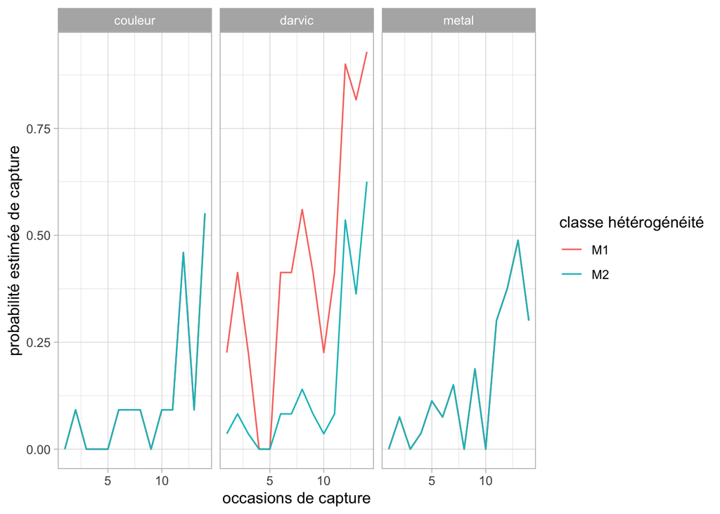

```r
p.estim <- data.frame(couleur = pcouleur[-c(1,16),1],
                      darvic = pdarvic[-c(1,30),1],
                      metal = pmetal[-c(1,16),1],
                      mixture = c(rep("M1", 14), rep("M2", 14)),
                      occ = c(1:14, 1:14))
p.estim <- tidyr::pivot_longer(p.estim,
                               cols = couleur:metal,
                               names_to = "type_bague",
                               values_to = "p_estim")
ggplot(data = p.estim,
       aes(x = occ, y = p_estim, color = mixture)) +
  geom_line() +
  facet_wrap(~type_bague) +
  theme_light() +
  labs(x = "occasions de capture",
       y = "probabilité estimée de capture",
       color = "classe hétérogénéité")
```

# Partie 4 : cistudes

On passe à l’exercice sur les cistudes.

Les données

```r
dat <- read_csv2("dat/BDD-CMR-Cistudes-Vigueirat.csv")
dat <- janitor::clean_names(dat)
```

Quelles sont les années avec le plus de marquages et recaptures?

```r
dat %>%
  count(action, mois, annee, sort = TRUE)
```

```
## # A tibble: 168 x 4
##    action     mois annee     n
##    <chr>     <dbl> <dbl> <int>
##  1 Recapture     4  2007   114
##  2 Recapture     6  2007    65
##  3 Marquage      6  1997    50
##  4 Recapture     7  2006    44
##  5 Recapture     5  2007    38
##  6 Recapture     3  2007    37
##  7 Marquage      7  2006    33
##  8 Recapture     8  2006    31
##  9 Marquage      4  2007    27
## 10 Marquage      9  2005    26
## # … with 158 more rows
```

```r
dat <- dat %>% select(id_ind, jour, mois, annee)
```

On extrait les mois de juin des années 1997 et 2007.

```r
dat1997 <- dat %>%
  filter(mois == 6, annee == 1997) %>%
  select(id_ind, jour) %>%
  add_column(det = 1) %>%
  arrange(id_ind)
dat2007 <- dat %>%
  filter(mois == 6, annee == 2007) %>%
  select(id_ind, jour) %>%
  add_column(det = 1) %>%
  arrange(id_ind)
```

On fait les histoires pour 1997.

```r
histories1997 <- dat1997 %>%
  group_by(id_ind) %>%
  mutate(id2 = row_number()) %>%
  pivot_wider(values_from = det,
              names_from = jour) %>% # les jours en colonnes
  select(-id2) %>%
  group_by(id_ind) %>%
  summarise(across(everything(), sum, na.rm = TRUE)) %>% # on rassemble les evenements pour chaque ind
  select(-id_ind)
histories1997[is.na(histories1997)] <- 0 # les Na sont des non-détections = 0
histories1997[histories1997 > 1] <- 1 # les observations mens multiples = 1
(histories1997 <- as.matrix(histories1997))
```

```
##       7 13 10 12 25 27 3 6 11 29 14 15 16 17 18 19 20 26 30
##  [1,] 1  0  0  0  0  0 0 0  0  0  0  0  0  0  0  0  0  0  0
##  [2,] 0  1  0  0  0  0 0 0  0  0  0  0  0  0  0  0  0  0  0
##  [3,] 0  0  1  0  0  0 0 0  0  0  0  0  0  0  0  0  0  0  0
##  [4,] 0  0  0  1  1  0 0 0  0  0  0  0  0  0  0  0  0  0  0
##  [5,] 0  0  1  0  1  0 0 0  0  0  0  0  0  0  0  0  0  0  0
##  [6,] 0  0  0  0  0  1 0 0  0  0  0  0  0  0  0  0  0  0  0
##  [7,] 0  0  0  0  0  0 1 0  0  0  0  0  0  0  0  0  0  0  0
##  [8,] 0  0  0  0  0  0 0 1  0  0  0  0  0  0  0  0  0  0  0
##  [9,] 0  0  0  0  0  0 0 1  0  0  0  0  0  0  0  0  0  0  0
## [10,] 0  0  0  0  0  0 0 1  0  0  0  0  0  0  0  0  0  0  0
## [11,] 0  0  1  0  0  0 0 0  0  0  0  0  0  0  0  0  0  0  0
## [12,] 0  0  1  0  0  0 0 0  0  0  0  0  0  0  0  0  0  0  0
## [13,] 0  0  1  0  0  0 0 0  0  0  0  0  0  0  0  0  0  0  0
## [14,] 0  0  1  0  0  0 0 0  0  0  0  0  0  0  0  0  0  0  0
```

[output cut: 42 more lines]

Et pour 2007.

```r
histories2007 <- dat2007 %>%
  group_by(id_ind) %>%
  mutate(id2 = row_number()) %>%
  pivot_wider(values_from = det,
              names_from = jour) %>% # les jours en colonnes
  select(-id2) %>%
  group_by(id_ind) %>%
  summarise(across(everything(), sum, na.rm = TRUE)) %>% # on rassemble les evenements pour chaque ind
  select(-id_ind)
histories2007[is.na(histories2007)] <- 0 # les Na sont des non-détections = 0
histories2007[histories2007 > 1] <- 1 # les observations mens multiples = 1
(histories2007 <- as.matrix(histories2007))
```

```
##       18 13 16 25 28 20 26 4 8 11 22 14 12 21 27 5 6 24 1 19 29 7
##  [1,]  1  0  0  0  0  0  0 0 0  0  0  0  0  0  0 0 0  0 0  0  0 0
##  [2,]  0  1  1  1  1  0  0 0 0  0  0  0  0  0  0 0 0  0 0  0  0 0
##  [3,]  0  0  0  0  0  1  0 0 0  0  0  0  0  0  0 0 0  0 0  0  0 0
##  [4,]  0  0  0  0  0  0  1 0 0  0  0  0  0  0  0 0 0  0 0  0  0 0
##  [5,]  0  0  0  0  0  0  0 1 0  0  0  0  0  0  0 0 0  0 0  0  0 0
##  [6,]  0  0  0  0  0  1  0 0 0  0  0  0  0  0  0 0 0  0 0  0  0 0
##  [7,]  0  0  0  0  1  0  0 0 0  0  0  0  0  0  0 0 0  0 0  0  0 0
##  [8,]  0  0  0  0  0  0  0 0 1  1  0  0  0  0  0 0 0  0 0  0  0 0
##  [9,]  0  0  0  0  0  0  1 0 0  0  1  0  0  0  0 0 0  0 0  0  0 0
## [10,]  0  0  0  0  0  0  0 0 0  0  0  1  0  0  0 0 0  0 0  0  0 0
## [11,]  0  0  0  0  0  0  0 0 0  0  0  0  1  0  0 0 0  0 0  0  0 0
## [12,]  0  0  0  0  0  0  0 0 0  0  0  0  0  1  0 0 0  0 0  0  0 0
## [13,]  0  0  0  0  0  0  0 1 0  0  0  0  0  0  0 0 0  0 0  0  0 0
## [14,]  0  0  0  0  1  0  0 0 0  0  0  0  0  0  0 0 0  0 0  0  0 0
```

[output cut: 55 more lines]

On fait les tests et l’ajustement pour 1997.

```r
cistude <- data.frame(ch = collapseCH(histories1997), freq = rep(1, nrow(histories1997)))
head(cistude)
```

```
##                    ch freq
## 1 1000000000000000000    1
## 2 0100000000000000000    1
## 3 0010000000000000000    1
## 4 0001100000000000000    1
## 5 0010100000000000000    1
## 6 0000010000000000000    1
```

```r
tail(cistude)
```

```
##                     ch freq
## 51 0000010000000000000    1
## 52 0000010000000000000    1
## 53 0000010000000000000    1
## 54 0000010000000000000    1
## 55 0000000000000000001    1
## 56 0000000000000000001    1
```

On fait les tests de fermeture.

```r
cistude_secr <- unRMarkInput(cistude) # on convertit au bon format
summary(cistude_secr) # resumes
```

```
## Object class       capthist
##
## Counts by occasion
##             1  2  3  4  5  6  7  8  9 10 11 12 13 14 15 16 17 18 19 Total
## n           1  9  6  6  7  5  1  3  5  1  3  1  2  1  2  3  2  1  2    61
## u           1  9  6  6  5  5  1  3  3  0  3  1  2  1  2  3  2  1  2    56
## f          51  5  0  0  0  0  0  0  0  0  0  0  0  0  0  0  0  0  0    56
## M(t+1)      1 10 16 22 27 32 33 36 39 39 42 43 45 46 48 51 53 54 56    56
## losses      0  0  0  0  0  0  0  0  0  0  0  0  0  0  0  0  0  0  0     0
## detections  1  9  6  6  7  5  1  3  5  1  3  1  2  1  2  3  2  1  2    61
```

```r
closure.test(cistude_secr, SB = TRUE)
```

```
## $Otis
##  statistic          p
##  -1.783585 0.03724554
##
## $Xc
##  statistic df         p
##   7.130646 17 0.9817931
##
## $NRvsJS
##  statistic df p
##          0  0 1
##
## $NMvsJS
##  statistic df p
##          0  0 1
##
## $MtvsNR
##  statistic df         p
##   7.130646 17 0.9817931
##
## $MtvsNM
##  statistic df         p
##   7.130646 17 0.9817931
##
## $compNRvsJS
##    Occasion Chisquare df  p
## 1         2        NA NA NA
## 2         3        NA NA NA
## 3         4        NA NA NA
## 4         5        NA NA NA
## 5         6        NA NA NA
## 6         7        NA NA NA
## 7         8        NA NA NA
## 8         9        NA NA NA
## 9        10        NA NA NA
## 10       11        NA NA NA
## 11       12        NA NA NA
## 12       13        NA NA NA
## 13       14        NA NA NA
## 14       15        NA NA NA
```

[output cut: 8 more lines]

```
## 3         4        NA NA NA
## 4         5        NA NA NA
## 5         6        NA NA NA
## 6         7        NA NA NA
## 7         8        NA NA NA
## 8         9        NA NA NA
## 9        10        NA NA NA
## 10       11        NA NA NA
## 11       12        NA NA NA
## 12       13        NA NA NA
## 13       14        NA NA NA
## 14       15        NA NA NA
## 15       16        NA NA NA
## 16       17        NA NA NA
## 17       18        NA NA NA
```

Process data

```r
cistude.proc <- process.data(cistude, begin.time = 1, model = "FullHet")
```

Create default design data

```r
cistude.ddl <- make.design.data(cistude.proc)
```

```r
run.cistude <- function() {

  p.dot <- list(formula =  ~ 1, share = TRUE)
  p.dot.behav <- list(formula =  ~ 1, share = FALSE)
  p.time <- list(formula =  ~ time, share = TRUE)
  p.time.behav <- list(formula =  ~ time, share = FALSE)
  p.h <- list(formula = ~ mixture, share = TRUE)
  p.h.behav <- list(formula = ~ mixture, share = FALSE)
  p.h.time <- list(formula = ~ time + mixture, share = TRUE)
  p.h.time.behav <- list(formula = ~ time + mixture, share = FALSE)

  cistude.model.list <- create.model.list("FullHet")

  cistude.results <- mark.wrapper(cistude.model.list,
                              data = cistude.proc,
                              ddl = cistude.ddl)

  return(cistude.results)
}
```

Run the models and examine the output

```r
cistude.results <- run.cistude()
```

```
##
## Output summary for FullHet model
## Name : pi(~1)p(~1)c()f0(~1)
##
## Npar :  3  (unadjusted=2)
## -2lnL:  46.99586
## AICc :  53.0185  (unadjusted=51.007166)
##
## Beta
##                     estimate        se           lcl           ucl
## pi:(Intercept) -9.843987e-05 0.0000000 -9.843987e-05 -9.843987e-05
## p:(Intercept)  -4.617108e+00 0.0640945 -4.742733e+00 -4.491482e+00
## f0:(Intercept)  5.606238e+00 0.0753810  5.458491e+00  5.753985e+00
##
##
## Real Parameter pi
##
##
## mixture:1 0.4999754
##
##
## Real Parameter p
##
##                   1         2         3         4         5         6         7
## mixture:1 0.0097847 0.0097847 0.0097847 0.0097847 0.0097847 0.0097847 0.0097847
## mixture:2 0.0097847 0.0097847 0.0097847 0.0097847 0.0097847 0.0097847 0.0097847
##                   8         9        10        11        12        13        14
## mixture:1 0.0097847 0.0097847 0.0097847 0.0097847 0.0097847 0.0097847 0.0097847
## mixture:2 0.0097847 0.0097847 0.0097847 0.0097847 0.0097847 0.0097847 0.0097847
##                  15        16        17        18        19
## mixture:1 0.0097847 0.0097847 0.0097847 0.0097847 0.0097847
## mixture:2 0.0097847 0.0097847 0.0097847 0.0097847 0.0097847
##
##
## Real Parameter c
##
##                   2         3         4         5         6         7         8
## mixture:1 0.0097847 0.0097847 0.0097847 0.0097847 0.0097847 0.0097847 0.0097847
## mixture:2 0.0097847 0.0097847 0.0097847 0.0097847 0.0097847 0.0097847 0.0097847
##                   9        10        11        12        13        14        15
```

[output cut: 439 more lines]

```
##                   2         3         4         5         6         7         8
## mixture:1 0.0078493 0.0078493 0.0078493 0.0078493 0.0078493 0.0078493 0.0078493
## mixture:2 0.0078493 0.0078493 0.0078493 0.0078493 0.0078493 0.0078493 0.0078493
##                   9        10        11        12        13        14        15
## mixture:1 0.0078493 0.0078493 0.0078493 0.0078493 0.0078493 0.0078493 0.0078493
## mixture:2 0.0078493 0.0078493 0.0078493 0.0078493 0.0078493 0.0078493 0.0078493
##                  16        17        18        19
## mixture:1 0.0078493 0.0078493 0.0078493 0.0078493
## mixture:2 0.0078493 0.0078493 0.0078493 0.0078493
##
##
## Real Parameter f0
##
##             1
##  1.190225e-09
```

Examine model-selection table

```r
cistude.results
```

```
##                                 model npar     AICc DeltaAICc weight Deviance
## 1                pi(~1)p(~1)c()f0(~1)    3 53.01850        NA     NA 67.14458
## 2              pi(~1)p(~1)c(~1)f0(~1)    3 43.02698        NA     NA 57.15306
## 3          pi(~1)p(~mixture)c()f0(~1)    4 55.03363        NA     NA 67.14458
## 4        pi(~1)p(~mixture)c(~1)f0(~1)    5       NA        NA     NA  2.00000
## 5   pi(~1)p(~time + mixture)c()f0(~1)   22 61.09470        NA     NA 36.27128
## 6 pi(~1)p(~time + mixture)c(~1)f0(~1)   23 59.43123        NA     NA 32.51841
## 7             pi(~1)p(~time)c()f0(~1)   21 59.00931        NA     NA 36.27128
## 8           pi(~1)p(~time)c(~1)f0(~1)   22 57.34183        NA     NA 32.51841
```

examine model names and find the name of the top model

```r
names(cistude.results)
```

```
## [1] "p.dot"          "p.dot.behav"    "p.h"            "p.h.behav"
## [5] "p.h.time"       "p.h.time.behav" "p.time"         "p.time.behav"
## [9] "model.table"
```

```r
cistude.results$p.dot$results$real
```

```
##                estimate           se         lcl         ucl fixed note
## pi g1 m1      0.4999754 0.000000e+00   0.4999754   0.4999754
## p g1 t1 m1    0.0097847 6.210056e-04   0.0086395   0.0110799
## f0 g1 a0 t1 272.1186200 2.051258e+01 234.7921100 315.3791600
```

```r
cistude.results$p.dot$results$derived
```

```
## $`N Population Size`
##   estimate      lcl      ucl
## 1 328.1186 290.7921 371.3792
```

Idem avec 2007.

```r
cistude <- data.frame(ch = collapseCH(histories2007), freq = rep(1, nrow(histories2007)))
head(cistude)
```

```
##                       ch freq
## 1 1000000000000000000000    1
## 2 0111100000000000000000    1
## 3 0000010000000000000000    1
## 4 0000001000000000000000    1
## 5 0000000100000000000000    1
## 6 0000010000000000000000    1
```

```r
tail(cistude)
```

```
##                        ch freq
## 64 0000000010000000000000    1
## 65 0000000001000000000000    1
## 66 0000000000110000000000    1
## 67 1000000000000000000000    1
## 68 1000000000000000000000    1
## 69 1000000000000000000100    1
```

On fait les tests de fermeture.

```r
cistude_secr <- unRMarkInput(cistude) # on convertit au bon format
summary(cistude_secr) # resumes
```

```
## Object class       capthist
##
## Counts by occasion
##             1  2  3  4  5  6  7  8  9 10 11 12 13 14 15 16 17 18 19 20 21 22
## n           7  3  1  4  5  6  4  8  3  3  3  3  1  6  2  7  4  1  3  2  1  2
## u           7  3  0  3  4  6  4  8  3  2  2  2  1  5  2  6  3  1  3  1  1  2
## f          61  7  0  1  0  0  0  0  0  0  0  0  0  0  0  0  0  0  0  0  0  0
## M(t+1)      7 10 10 13 17 23 27 35 38 40 42 44 45 50 52 58 61 62 65 66 67 69
## losses      0  0  0  0  0  0  0  0  0  0  0  0  0  0  0  0  0  0  0  0  0  0
## detections  7  3  1  4  5  6  4  8  3  3  3  3  1  6  2  7  4  1  3  2  1  2
##            Total
## n             79
## u             69
## f             69
## M(t+1)        69
## losses         0
## detections    79
```

```r
closure.test(cistude_secr, SB = TRUE)
```

```
## $Otis
##  statistic          p
##  -2.169297 0.01503008
##
## $Xc
##  statistic df         p
##   25.54082 20 0.1815182
##
## $NRvsJS
##  statistic df p
##          0  0 1
##
## $NMvsJS
##  statistic df p
##          0  0 1
##
## $MtvsNR
##  statistic df         p
##   25.54082 20 0.1815182
##
## $MtvsNM
##  statistic df         p
##   25.54082 20 0.1815182
##
## $compNRvsJS
##    Occasion Chisquare df  p
## 1         2        NA NA NA
## 2         3        NA NA NA
## 3         4        NA NA NA
## 4         5        NA NA NA
## 5         6        NA NA NA
## 6         7        NA NA NA
## 7         8        NA NA NA
## 8         9        NA NA NA
## 9        10        NA NA NA
## 10       11        NA NA NA
## 11       12        NA NA NA
## 12       13        NA NA NA
## 13       14        NA NA NA
## 14       15        NA NA NA
```

[output cut: 14 more lines]

```
## 6         7        NA NA NA
## 7         8        NA NA NA
## 8         9        NA NA NA
## 9        10        NA NA NA
## 10       11        NA NA NA
## 11       12        NA NA NA
## 12       13        NA NA NA
## 13       14        NA NA NA
## 14       15        NA NA NA
## 15       16        NA NA NA
## 16       17        NA NA NA
## 17       18        NA NA NA
## 18       19        NA NA NA
## 19       20        NA NA NA
## 20       21        NA NA NA
```

Process data

```r
cistude.proc <- process.data(cistude, begin.time = 1, model = "FullHet")
```

Create default design data

```r
cistude.ddl <- make.design.data(cistude.proc)
```

```r
run.cistude <- function() {

  p.dot <- list(formula =  ~ 1, share = TRUE)
  p.dot.behav <- list(formula =  ~ 1, share = FALSE)
  p.time <- list(formula =  ~ time, share = TRUE)
  p.time.behav <- list(formula =  ~ time, share = FALSE)
  p.h <- list(formula = ~ mixture, share = TRUE)
  p.h.behav <- list(formula = ~ mixture, share = FALSE)
  p.h.time <- list(formula = ~ time + mixture, share = TRUE)
  p.h.time.behav <- list(formula = ~ time + mixture, share = FALSE)

  cistude.model.list <- create.model.list("FullHet")

  cistude.results <- mark.wrapper(cistude.model.list,
                              data = cistude.proc,
                              ddl = cistude.ddl)

  return(cistude.results)
}
```

Run the models and examine the output

```r
cistude.results <- run.cistude()
```

[output not shown]

[output cut: 469 more lines]

```
##                   2         3         4         5         6         7         8
## mixture:1 0.0120193 0.0120193 0.0120193 0.0120193 0.0120193 0.0120193 0.0120193
## mixture:2 0.0120193 0.0120193 0.0120193 0.0120193 0.0120193 0.0120193 0.0120193
##                   9        10        11        12        13        14        15
## mixture:1 0.0120193 0.0120193 0.0120193 0.0120193 0.0120193 0.0120193 0.0120193
## mixture:2 0.0120193 0.0120193 0.0120193 0.0120193 0.0120193 0.0120193 0.0120193
##                  16        17        18        19        20        21        22
## mixture:1 0.0120193 0.0120193 0.0120193 0.0120193 0.0120193 0.0120193 0.0120193
## mixture:2 0.0120193 0.0120193 0.0120193 0.0120193 0.0120193 0.0120193 0.0120193
##
##
## Real Parameter f0
##
##             1
##  3.408625e-09
```

Examine model-selection table

```r
cistude.results
```

```
##                                 model npar      AICc  DeltaAICc       weight
## 3          pi(~1)p(~mixture)c()f0(~1)    4  91.24373  0.0000000 3.159467e-01
## 2              pi(~1)p(~1)c(~1)f0(~1)    4  91.49273  0.2489940 2.789623e-01
## 1                pi(~1)p(~1)c()f0(~1)    3  92.00888  0.7651525 2.155079e-01
## 4        pi(~1)p(~mixture)c(~1)f0(~1)    5  92.28317  1.0394370 1.878897e-01
## 8           pi(~1)p(~time)c(~1)f0(~1)   25 102.48875 11.2450181 1.142324e-03
## 6 pi(~1)p(~time + mixture)c(~1)f0(~1)   26 104.55909 13.3153554 4.057151e-04
## 5   pi(~1)p(~time + mixture)c()f0(~1)   25 107.63693 16.3932001 8.707143e-05
## 7             pi(~1)p(~time)c()f0(~1)   24 108.43880 17.1950653 5.831132e-05
##    Deviance
## 3 112.66139
## 2 112.91038
## 1 115.43712
## 4 111.68758
## 8  81.06153
## 6  81.06153
## 5  86.20971
## 7  89.07914
```

examine model names and find the name of the top model

```r
names(cistude.results)
```

```
## [1] "p.dot"          "p.dot.behav"    "p.h"            "p.h.behav"
## [5] "p.h.time"       "p.h.time.behav" "p.time"         "p.time.behav"
## [9] "model.table"
```

```r
cistude.results$p.dot$results$real
```

```
##                estimate se         lcl         ucl fixed note
## pi g1 m1      0.4999895  0   0.4999895   0.4999895
## p g1 t1 m1    0.0133212  0   0.0133212   0.0133212
## f0 g1 a0 t1 200.5634600  0 200.5634600 200.5634600
```

```r
cistude.results$p.dot$results$derived
```

```
## $`N Population Size`
##   estimate      lcl      ucl
## 1 269.5635 269.5635 269.5635
```

# Partie 5 : monarques

On passe à l’analyse des données monarques.

Les données.

```r
dat <- readxl::read_xlsx("dat/CMR-Monarque-2019.xlsx") %>%
  janitor::clean_names() %>%
  select(session, identifiant) %>%
  filter(identifiant != 0) %>%
  add_column(det = 1) %>%
  arrange(identifiant)
dat
```

```
## # A tibble: 327 x 3
##    session   identifiant   det
##    <chr>           <dbl> <dbl>
##  1 Session 1           1     1
##  2 Session 1           2     1
##  3 Session 1           3     1
##  4 Session 2           3     1
##  5 Session 1           4     1
##  6 Session 2           4     1
##  7 Session 1           5     1
##  8 Session 1           6     1
##  9 Session 4           6     1
## 10 Session 1           7     1
## # … with 317 more rows
```

On construit les histoire de capture.

```r
histoires <- dat %>%
  group_by(identifiant) %>%
  mutate(id2 = row_number()) %>%
  pivot_wider(values_from = det,
              names_from = session) %>% # les jours en colonnes
  select(-id2) %>%
  group_by(identifiant) %>%
  summarise(across(everything(), sum, na.rm = TRUE)) %>% # on rassemble les evenements pour chaque ind
  select(-identifiant)
histoires[is.na(histoires)] <- 0 # les Na sont des non-détections = 0
histoires[histoires > 1] <- 1 # les observations mens multiples = 1
(histoires <- as.matrix(histoires))
```

```
##        Session 1 Session 2 Session 4 Session 3 Session 5 Session 6 Session 8
##   [1,]         1         0         0         0         0         0         0
##   [2,]         1         0         0         0         0         0         0
##   [3,]         1         1         0         0         0         0         0
##   [4,]         1         1         0         0         0         0         0
##   [5,]         1         0         0         0         0         0         0
##   [6,]         1         0         1         0         0         0         0
##   [7,]         1         0         0         0         0         0         0
##   [8,]         1         1         1         1         0         0         0
##   [9,]         1         0         0         0         0         0         0
##  [10,]         1         0         0         0         0         0         0
##  [11,]         1         0         0         0         0         0         0
##  [12,]         1         0         0         0         0         0         0
##  [13,]         1         0         0         0         0         0         0
##  [14,]         1         0         0         0         0         0         0
```

[output cut: 521 more lines]

On fait les tests et l’ajustement.

```r
monarque <- data.frame(ch = collapseCH(histoires), freq = rep(1, nrow(histoires)))
head(monarque)
```

```
##           ch freq
## 1 1000000000    1
## 2 1000000000    1
## 3 1100000000    1
## 4 1100000000    1
## 5 1000000000    1
## 6 1010000000    1
```

```r
tail(monarque)
```

```
##             ch freq
## 262 0000001000    1
## 263 0000001000    1
## 264 0000001001    1
## 265 0000001000    1
## 266 0000001000    1
## 267 0000000001    1
```

On fait les tests de fermeture.

```r
monarque_secr <- unRMarkInput(monarque) # on convertit au bon format
summary(monarque_secr) # resumes
```

```
## Object class       capthist
##
## Counts by occasion
##              1  2   3   4   5   6   7   8   9  10 Total
## n           16 28  84  37  65  49  23  21   1   3   327
## u           16 25  79  27  53  34  20  12   0   1   267
## f          216 44   5   2   0   0   0   0   0   0   267
## M(t+1)      16 41 120 147 200 234 254 266 266 267   267
## losses       0  0   0   0   0   0   0   0   0   0     0
## detections  16 28  84  37  65  49  23  21   1   3   327
```

```r
closure.test(monarque_secr, SB = TRUE)
```

```
## $Otis
##  statistic            p
##  -5.547468 1.449177e-08
##
## $Xc
##  statistic df p
##   141.1563 12 0
##
## $NRvsJS
##  statistic df            p
##   19.87966  4 0.0005274697
##
## $NMvsJS
##  statistic df           p
##   16.07242  4 0.002923506
##
## $MtvsNR
##  statistic df p
##   121.2766  8 0
##
## $MtvsNM
##  statistic df p
##   125.0839  8 0
##
## $compNRvsJS
##   Occasion Chisquare df           p
## 1        2        NA NA          NA
## 2        3 0.5053096  1 0.477176389
## 3        4 7.3648815  1 0.006650998
## 4        5 4.1689058  1 0.041172382
## 5        6 7.8405619  1 0.005108672
## 6        7        NA NA          NA
## 7        8        NA NA          NA
## 8        9        NA NA          NA
##
## $compNMvsJS
##   Occasion   Chisquare df            p
## 1        2  3.55114885  1 0.0595042378
## 2        3  0.20746622  1 0.6487606427
## 3        4  0.02747251  1 0.8683550038
## 4        5 12.28633623  1 0.0004562866
## 5        6          NA NA           NA
## 6        7          NA NA           NA
## 7        8          NA NA           NA
## 8        9          NA NA           NA
```

On sélectionne les occasions 2 à 5.

```r
monarque_reduced <- monarque
ch <- splitCH(monarque_reduced$ch) # sépare colonnes
head(ch)
```

```
##      Time1 Time2 Time3 Time4 Time5 Time6 Time7 Time8 Time9 Time10
## [1,]     1     0     0     0     0     0     0     0     0      0
## [2,]     1     0     0     0     0     0     0     0     0      0
## [3,]     1     1     0     0     0     0     0     0     0      0
## [4,]     1     1     0     0     0     0     0     0     0      0
## [5,]     1     0     0     0     0     0     0     0     0      0
## [6,]     1     0     1     0     0     0     0     0     0      0
```

```r
ch_reduced <- ch[, 2:5] # sélection colonnes 2 à 5
head(ch_reduced)
```

```
##      Time2 Time3 Time4 Time5
## [1,]     0     0     0     0
## [2,]     0     0     0     0
## [3,]     1     0     0     0
## [4,]     1     0     0     0
## [5,]     0     0     0     0
## [6,]     0     1     0     0
```

```r
dim(ch_reduced)
```

```
## [1] 267   4
```

```r
mask <- apply(ch_reduced, 1, sum)
ch_reduced <- ch_reduced[mask > 0,] # supprime lignes de 0
head(ch_reduced)
```

```
##      Time2 Time3 Time4 Time5
## [1,]     1     0     0     0
## [2,]     1     0     0     0
## [3,]     0     1     0     0
## [4,]     1     1     1     0
## [5,]     1     0     0     0
## [6,]     1     0     1     0
```

```r
dim(ch_reduced)
```

```
## [1] 188   4
```

```r
freq_reduced <- monarque_reduced$freq[mask > 0]
length(freq_reduced)
```

```
## [1] 188
```

```r
monarque_reduced <- data.frame(ch = collapseCH(ch_reduced), # on recolle les colonnes ensemble
                             freq = freq_reduced)
monarque_reduced_secr <- unRMarkInput(monarque_reduced) # on convertit au bon format
```

Jette un coup d’oeil.

```r
summary(monarque_reduced_secr)
```

```
## Object class       capthist
##
## Counts by occasion
##              1   2   3   4 Total
## n           28  84  37  65   214
## u           28  80  27  53   188
## f          165  20   3   0   188
## M(t+1)      28 108 135 188   188
## losses       0   0   0   0     0
## detections  28  84  37  65   214
```

On refait les tests de Stanley et Burnham et de Otis.

```r
closure.test(monarque_reduced_secr, SB = TRUE)
```

```
## $Otis
##  statistic         p
##      -0.55 0.2911597
##
## $Xc
##  statistic df         p
##   2.960724  4 0.5644195
##
## $NRvsJS
##  statistic df         p
##    2.44383  2 0.2946653
##
## $NMvsJS
##  statistic df         p
##  0.2619026  2 0.8772605
##
## $MtvsNR
##  statistic df         p
##  0.5168942  2 0.7722499
##
## $MtvsNM
##  statistic df        p
##   2.698822  2 0.259393
##
## $compNRvsJS
##   Occasion Chisquare df         p
## 1        2 0.1051976  1 0.7456792
## 2        3 2.3386325  1 0.1262003
##
## $compNMvsJS
##   Occasion Chisquare df         p
## 1        2 0.2235364  1 0.6363585
## 2        3 0.0383662  1 0.8447096
```

On passe aux analyses.

```r
monarque.proc <- process.data(monarque_reduced, begin.time = 1, model = "FullHet")
```

Create default design data

```r
monarque.ddl <- make.design.data(monarque.proc)
```

```r
run.monarque <- function() {

  p.dot <- list(formula =  ~ 1, share = TRUE)
  p.dot.behav <- list(formula =  ~ 1, share = FALSE)
  p.time <- list(formula =  ~ time, share = TRUE)
  p.time.behav <- list(formula =  ~ time, share = FALSE)
  p.h <- list(formula = ~ mixture, share = TRUE)
  p.h.behav <- list(formula = ~ mixture, share = FALSE)
  p.h.time <- list(formula = ~ time + mixture, share = TRUE)
  p.h.time.behav <- list(formula = ~ time + mixture, share = FALSE)

  monarque.model.list <- create.model.list("FullHet")

  monarque.results <- mark.wrapper(monarque.model.list,
                              data = monarque.proc,
                              ddl = monarque.ddl)

  return(monarque.results)
}
```

Run the models and examine the output

```r
monarque.results <- run.monarque()
```

```
##
## Output summary for FullHet model
## Name : pi(~1)p(~1)c()f0(~1)
##
## Npar :  2  (unadjusted=3)
## -2lnL:  -896.4989
## AICc :  -892.4829  (unadjusted=-892.48287)
##
## Beta
##                 estimate se       lcl       ucl
## pi:(Intercept)  0.000000  0  0.000000  0.000000
## p:(Intercept)  -2.359285  0 -2.359285 -2.359285
## f0:(Intercept)  6.067756  0  6.067756  6.067756
##
##
## Real Parameter pi
##
##
## mixture:1 0.5
##
##
## Real Parameter p
##
##                   1         2         3         4
## mixture:1 0.0863306 0.0863306 0.0863306 0.0863306
## mixture:2 0.0863306 0.0863306 0.0863306 0.0863306
##
##
## Real Parameter c
##
##                   2         3         4
## mixture:1 0.0863306 0.0863306 0.0863306
## mixture:2 0.0863306 0.0863306 0.0863306
##
##
## Real Parameter f0
##
##         1
##  431.7108
##
```

[output cut: 277 more lines]

```
## mixture:1 0.1489366 0.4999998 0.3374997 1
## mixture:2 0.1489366 0.4999998 0.3374997 1
##
##
## Real Parameter c
##
##                   2         3         4
## mixture:1 0.0959409 0.0959409 0.0959409
## mixture:2 0.0959409 0.0959409 0.0959409
##
##
## Real Parameter f0
##
##             1
##  1.441863e-09
```

Examine model-selection table

```r
monarque.results
```

```
##                                 model npar      AICc DeltaAICc       weight
## 8           pi(~1)p(~time)c(~1)f0(~1)    7 -932.1677  0.000000 6.714966e-01
## 6 pi(~1)p(~time + mixture)c(~1)f0(~1)    8 -930.1244  2.043271 2.417426e-01
## 7             pi(~1)p(~time)c()f0(~1)    5 -927.5998  4.567831 6.841508e-02
## 5   pi(~1)p(~time + mixture)c()f0(~1)    7 -924.9674  7.200220 1.834577e-02
## 1                pi(~1)p(~1)c()f0(~1)    2 -892.4829 39.684794 1.620318e-09
## 2              pi(~1)p(~1)c(~1)f0(~1)    4 -892.2880 39.879630 1.469915e-09
## 4        pi(~1)p(~mixture)c(~1)f0(~1)    5 -890.2598 41.907841 5.331774e-10
## 3          pi(~1)p(~mixture)c()f0(~1)    4 -889.6412 42.526460 3.913275e-10
##   Deviance
## 8 19.67130
## 6 19.67130
## 7 28.30923
## 5 26.87151
## 1 69.49060
## 2 65.64791
## 4 65.64924
## 3 68.29474
```

examine model names and find the name of the top model

```r
names(monarque.results)
```

```
## [1] "p.dot"          "p.dot.behav"    "p.h"            "p.h.behav"
## [5] "p.h.time"       "p.h.time.behav" "p.time"         "p.time.behav"
## [9] "model.table"
```

examine the output from top-ranked model (#8)

```r
monarque.results$p.time.behav$results$real
```

```
##                 estimate           se          lcl          ucl fixed note
## pi g1 m1    5.002057e-01 0.000000e+00 5.002057e-01 5.002057e-01
## p g1 t1 m1  1.489366e-01 2.596590e-02 1.048486e-01 2.072706e-01
## p g1 t2 m1  4.999998e-01 3.952850e-02 4.231382e-01 5.768615e-01
## p g1 t3 m1  3.374997e-01 5.286700e-02 2.427092e-01 4.474376e-01
## p g1 t4 m1  1.000000e+00 7.055214e-06 9.999862e-01 1.000014e+00
## c g1 t2 m1  9.594090e-02 1.789020e-02 6.614750e-02 1.371823e-01
## f0 g1 a0 t1 1.441863e-09 0.000000e+00 1.441863e-09 1.441863e-09
```

```r
monarque.results$p.time.behav$results$derived
```

```
## $`N Population Size`
##   estimate lcl ucl
## 1      188 188 188
```

Autre modèle.

```r
monarque.results$p.h.time.behav$results$real
```

```
##                 estimate           se          lcl          ucl fixed note
## pi g1 m1    9.981067e-01 0.000000e+00 9.981067e-01 9.981067e-01
## p g1 t1 m1  1.485335e-01 2.482221e-01 3.710000e-03 8.909706e-01
## p g1 t2 m1  4.996257e-01 0.000000e+00 4.996257e-01 4.996257e-01
## p g1 t3 m1  3.373099e-01 0.000000e+00 3.373099e-01 3.373099e-01
## p g1 t4 m1  1.000000e+00 4.496727e-06 9.999912e-01 1.000009e+00
## p g1 t1 m2  3.626218e-01 0.000000e+00 3.626218e-01 3.626218e-01
## p g1 t2 m2  7.650646e-01 0.000000e+00 7.650646e-01 7.650646e-01
## p g1 t3 m2  6.240658e-01 0.000000e+00 6.240658e-01 6.240658e-01
## p g1 t4 m2  1.000000e+00 1.351692e-06 9.999974e-01 1.000003e+00
## c g1 t2 m1  9.594100e-02 1.789020e-02 6.614750e-02 1.371824e-01
## f0 g1 a0 t1 1.696268e-13 1.907386e-09 3.572210e-17 8.054749e-10
```

```r
monarque.results$p.h.time.behav$results$derived
```

```
## $`N Population Size`
##   estimate lcl ucl
## 1      188 188 188
```

Autre modèle.

```r
monarque.results$p.time$results$real
```

```
##                estimate         se         lcl         ucl fixed note
## pi g1 m1      0.5000000  0.0000000   0.5000000   0.5000000
## p g1 t1 m1    0.0477867  0.0118658   0.0292227   0.0772056
## p g1 t2 m1    0.1433600  0.0278898   0.0968455   0.2070924
## p g1 t3 m1    0.0631466  0.0145333   0.0399802   0.0983614
## p g1 t4 m1    0.1109333  0.0225517   0.0738220   0.1634093
## f0 g1 a0 t1 397.9376500 97.4299360 247.9883100 638.5558200
```

```r
monarque.results$p.time$results$derived
```

```
## $`N Population Size`
##   estimate      lcl      ucl
## 1 585.9377 435.9883 826.5558
```

Modèle des diapos

```r
monarque.results$p.h.time$results$real
```

```
##                estimate           se          lcl          ucl fixed note
## pi g1 m1      0.0614291    0.1134539 1.381300e-03 7.559110e-01
## p g1 t1 m1    0.1352239    0.1878199 6.669100e-03 7.845706e-01
## p g1 t2 m1    0.3445876    0.3625949 2.210330e-02 9.244108e-01
## p g1 t3 m1    0.1739979    0.2307662 8.972300e-03 8.305445e-01
## p g1 t4 m1    0.2816069    0.3247905 1.657420e-02 9.011604e-01
## p g1 t1 m2    0.0174382    0.0577972 2.386644e-05 9.295643e-01
## p g1 t2 m2    0.0563126    0.1791517 8.055660e-05 9.778759e-01
## p g1 t3 m2    0.0233504    0.0769099 3.219808e-05 9.466746e-01
## p g1 t4 m2    0.0425960    0.1374777 6.008040e-05 9.705405e-01
## f0 g1 a0 t1 946.8118900 2530.1647000 5.541574e+01 1.617686e+04
```

```r
monarque.results$p.h.time$results$derived
```

```
## $`N Population Size`
##   estimate      lcl      ucl
## 1 1134.812 243.4157 16364.86
```

# Partie 6 : iguanes

## Données 2006

Les données

```r
iguane <- convert.inp("dat/iguanes-2006-2sexes-FM.inp",
                    group.df = data.frame(sex = c("F","M")),
                    covariates = NULL)
head(iguane)
```

```
##                    ch freq sex
## 1:1 00000000000001000    1   F
## 1:2 00000000000001000    1   F
## 1:3 00000000000010000    1   F
## 1:4 00010000000000000    1   F
## 1:5 00001000000000000    1   F
## 1:6 00000000000010000    1   F
```

```r
tail(iguane)
```

```
##                      ch freq sex
## 2:156 00000010000010000    1   M
## 2:157 00000001000000010    1   M
## 2:158 00000100100000000    1   M
## 2:159 00000010000000100    1   M
## 2:160 01000000100000000    1   M
## 2:161 01100000100000000    1   M
```

On sépare mâles et femelles.

```r
iguaneM <- iguane[iguane$sex == "M", ]
iguaneF <- iguane[iguane$sex == "F", ]
```

On formate les données.

```r
iguane_secr <- unRMarkInput(iguane) # on convertit au bon format
iguaneM_secr <- unRMarkInput(iguaneM) # on convertit au bon format
iguaneF_secr <- unRMarkInput(iguaneF) # on convertit au bon format
summary(iguane_secr) # resumes
```

```
## Object class       capthist
##
## Counts by occasion
##              1  2  3  4  5  6  7  8  9 10 11  12  13  14  15  16  17 Total
## n            1 10  4 11 12 11 13 10 10  4 18  17  16  11  12  19   1   180
## u            1 10  3 11 12 10 12 10  7  3 16  16  14  11   8  16   1   161
## f          145 13  3  0  0  0  0  0  0  0  0   0   0   0   0   0   0   161
## M(t+1)       1 11 14 25 37 47 59 69 76 79 95 111 125 136 144 160 161   161
## losses       0  0  0  0  0  0  0  0  0  0  0   0   0   0   0   0   0     0
## detections   1 10  4 11 12 11 13 10 10  4 18  17  16  11  12  19   1   180
##
## Individual covariates
##  sex
##  F:89
##  M:72
```

```r
summary(iguaneM_secr) # resumes
```

```
## Object class       capthist
##
## Counts by occasion
##             1 2  3  4  5  6  7  8  9 10 11 12 13 14 15 16 17 Total
## n           0 9  3  4  8  6  6  2  5  1  5  5  9  4  6  9  1    83
## u           0 9  2  4  8  5  5  2  2  1  5  5  8  4  4  7  1    72
## f          62 9  1  0  0  0  0  0  0  0  0  0  0  0  0  0  0    72
## M(t+1)      0 9 11 15 23 28 33 35 37 38 43 48 56 60 64 71 72    72
## losses      0 0  0  0  0  0  0  0  0  0  0  0  0  0  0  0  0     0
## detections  0 9  3  4  8  6  6  2  5  1  5  5  9  4  6  9  1    83
##
## Individual covariates
##  sex
##  M:72
```

```r
summary(iguaneF_secr) # resumes
```

```
## Object class       capthist
##
## Counts by occasion
##             1 2 3  4  5  6  7  8  9 10 11 12 13 14 15 16 17 Total
## n           1 1 1  7  4  5  7  8  5  3 13 12  7  7  6 10  0    97
## u           1 1 1  7  4  5  7  8  5  2 11 11  6  7  4  9  0    89
## f          83 4 2  0  0  0  0  0  0  0  0  0  0  0  0  0  0    89
## M(t+1)      1 2 3 10 14 19 26 34 39 41 52 63 69 76 80 89 89    89
## losses      0 0 0  0  0  0  0  0  0  0  0  0  0  0  0  0  0     0
## detections  1 1 1  7  4  5  7  8  5  3 13 12  7  7  6 10  0    97
##
## Individual covariates
##  sex
##  F:89
```

Les deux sexes ensemble.

```r
closure.test(iguane_secr, SB = TRUE)
```

```
## $Otis
##  statistic          p
##  -1.894954 0.02904928
##
## $Xc
##  statistic df         p
##   10.06825 16 0.8630401
##
## $NRvsJS
##  statistic df        p
##   1.475048  1 0.224551
##
## $NMvsJS
##   statistic df         p
##  0.04058442  1 0.8403422
##
## $MtvsNR
##  statistic df         p
##   8.593198 15 0.8978099
##
## $MtvsNM
##  statistic df         p
##   10.02766 15 0.8179963
##
## $compNRvsJS
##    Occasion Chisquare df        p
## 1         2        NA NA       NA
## 2         3        NA NA       NA
## 3         4        NA NA       NA
## 4         5        NA NA       NA
## 5         6        NA NA       NA
## 6         7        NA NA       NA
## 7         8        NA NA       NA
## 8         9        NA NA       NA
## 9        10        NA NA       NA
## 10       11        NA NA       NA
## 11       12        NA NA       NA
## 12       13        NA NA       NA
## 13       14        NA NA       NA
## 14       15  1.475048  1 0.224551
## 15       16        NA NA       NA
##
## $compNMvsJS
##    Occasion  Chisquare df         p
## 1         2         NA NA        NA
## 2         3         NA NA        NA
## 3         4 0.04058442  1 0.8403422
## 4         5         NA NA        NA
## 5         6         NA NA        NA
## 6         7         NA NA        NA
## 7         8         NA NA        NA
## 8         9         NA NA        NA
## 9        10         NA NA        NA
## 10       11         NA NA        NA
## 11       12         NA NA        NA
## 12       13         NA NA        NA
## 13       14         NA NA        NA
## 14       15         NA NA        NA
## 15       16         NA NA        NA
```

On fait les tests de fermeture, mâles d’abord.

```r
closure.test(iguaneM_secr, SB = TRUE)
```

```
## $Otis
##   statistic        p
##  -0.5883371 0.278153
##
## $Xc
##  statistic df  p
##          0 NA NA
##
## $NRvsJS
##  statistic df p
##          0  0 1
##
## $NMvsJS
##  statistic df p
##          0  0 1
##
## $MtvsNR
##  statistic df  p
##         NA NA NA
##
## $MtvsNM
##  statistic df  p
##         NA NA NA
##
## $compNRvsJS
##    Occasion Chisquare df  p
## 1         2        NA NA NA
## 2         3        NA NA NA
## 3         4        NA NA NA
## 4         5        NA NA NA
## 5         6        NA NA NA
## 6         7        NA NA NA
## 7         8        NA NA NA
## 8         9        NA NA NA
## 9        10        NA NA NA
## 10       11        NA NA NA
## 11       12        NA NA NA
## 12       13        NA NA NA
## 13       14        NA NA NA
## 14       15        NA NA NA
## 15       16        NA NA NA
##
## $compNMvsJS
##    Occasion Chisquare df  p
## 1         2        NA NA NA
## 2         3        NA NA NA
## 3         4        NA NA NA
## 4         5        NA NA NA
## 5         6        NA NA NA
## 6         7        NA NA NA
## 7         8        NA NA NA
## 8         9        NA NA NA
## 9        10        NA NA NA
## 10       11        NA NA NA
## 11       12        NA NA NA
## 12       13        NA NA NA
## 13       14        NA NA NA
## 14       15        NA NA NA
## 15       16        NA NA NA
```

Femelles ensuite

```r
closure.test(iguaneF_secr, SB = TRUE)
```

```
## $Otis
##  statistic          p
##  -1.813781 0.03485574
##
## $Xc
##  statistic df  p
##          0 NA NA
##
## $NRvsJS
##  statistic df p
##          0  0 1
##
## $NMvsJS
##  statistic df p
##          0  0 1
##
## $MtvsNR
##  statistic df  p
##         NA NA NA
##
## $MtvsNM
##  statistic df  p
##         NA NA NA
##
## $compNRvsJS
##    Occasion Chisquare df  p
## 1         2        NA NA NA
## 2         3        NA NA NA
## 3         4        NA NA NA
## 4         5        NA NA NA
## 5         6        NA NA NA
## 6         7        NA NA NA
## 7         8        NA NA NA
## 8         9        NA NA NA
## 9        10        NA NA NA
## 10       11        NA NA NA
## 11       12        NA NA NA
## 12       13        NA NA NA
## 13       14        NA NA NA
## 14       15        NA NA NA
## 15       16        NA NA NA
##
## $compNMvsJS
##    Occasion Chisquare df  p
## 1         2        NA NA NA
## 2         3        NA NA NA
## 3         4        NA NA NA
## 4         5        NA NA NA
## 5         6        NA NA NA
## 6         7        NA NA NA
## 7         8        NA NA NA
## 8         9        NA NA NA
## 9        10        NA NA NA
## 10       11        NA NA NA
## 11       12        NA NA NA
## 12       13        NA NA NA
## 13       14        NA NA NA
## 14       15        NA NA NA
## 15       16        NA NA NA
```

Les modèles maintenant. On commence par le jeu de données avec les deux sexes ensemble.

Process data

```r
iguane.proc <- process.data(iguane, begin.time = 1, model = "FullHet")
```

Create default design data

```r
iguane.ddl <- make.design.data(iguane.proc)
```

Liste des modèles.

```r
run.iguane <- function() {

  p.dot <- list(formula =  ~ 1, share = TRUE)
  p.dot.behav <- list(formula =  ~ 1, share = FALSE)
  p.time <- list(formula =  ~ time, share = TRUE)
  p.time.behav <- list(formula =  ~ time, share = FALSE)
  p.h <- list(formula = ~ mixture, share = TRUE)
  p.h.behav <- list(formula = ~ mixture, share = FALSE)
  p.h.time <- list(formula = ~ time + mixture, share = TRUE)
  p.h.time.behav <- list(formula = ~ time + mixture, share = FALSE)

  iguane.model.list <- create.model.list("FullHet")

  iguane.results <- mark.wrapper(iguane.model.list,
                              data = iguane.proc,
                              ddl = iguane.ddl)

  return(iguane.results)
}
```

Run the models and examine the output

```r
iguane.results <- run.iguane()
```

```
##
## Output summary for FullHet model
## Name : pi(~1)p(~1)c()f0(~1)
##
## Npar :  3  (unadjusted=2)
## -2lnL:  -203.4014
## AICc :  -197.3926  (unadjusted=-199.397)
##
## Beta
##                     estimate           se           lcl           ucl
## pi:(Intercept) -0.0001044497 0.000000e+00 -0.0001044497 -0.0001044497
## p:(Intercept)  -4.2377902000 9.257178e-08 -4.2377904000 -4.2377900000
## f0:(Intercept)  6.3679688000 8.910080e-02  6.1933312000  6.5426064000
##
##
## Real Parameter pi
##
##
## mixture:1 0.4999739
##
##
## Real Parameter p
##
##                   1         2         3         4         5         6         7
## mixture:1 0.0142339 0.0142339 0.0142339 0.0142339 0.0142339 0.0142339 0.0142339
## mixture:2 0.0142339 0.0142339 0.0142339 0.0142339 0.0142339 0.0142339 0.0142339
##                   8         9        10        11        12        13        14
## mixture:1 0.0142339 0.0142339 0.0142339 0.0142339 0.0142339 0.0142339 0.0142339
## mixture:2 0.0142339 0.0142339 0.0142339 0.0142339 0.0142339 0.0142339 0.0142339
##                  15        16        17
## mixture:1 0.0142339 0.0142339 0.0142339
## mixture:2 0.0142339 0.0142339 0.0142339
##
##
## Real Parameter c
##
##                   2         3         4         5         6         7         8
## mixture:1 0.0142339 0.0142339 0.0142339 0.0142339 0.0142339 0.0142339 0.0142339
## mixture:2 0.0142339 0.0142339 0.0142339 0.0142339 0.0142339 0.0142339 0.0142339
##                   9        10        11        12        13        14        15
```

[output cut: 434 more lines]

```
##                   2         3         4         5         6         7         8
## mixture:1 0.0159798 0.0159798 0.0159798 0.0159798 0.0159798 0.0159798 0.0159798
## mixture:2 0.0159798 0.0159798 0.0159798 0.0159798 0.0159798 0.0159798 0.0159798
##                   9        10        11        12        13        14        15
## mixture:1 0.0159798 0.0159798 0.0159798 0.0159798 0.0159798 0.0159798 0.0159798
## mixture:2 0.0159798 0.0159798 0.0159798 0.0159798 0.0159798 0.0159798 0.0159798
##                  16        17
## mixture:1 0.0159798 0.0159798
## mixture:2 0.0159798 0.0159798
##
##
## Real Parameter f0
##
##             1
##  2.397215e-08
```

Examine model-selection table

```r
iguane.results
```

```
##                                 model npar      AICc DeltaAICc       weight
## 8           pi(~1)p(~time)c(~1)f0(~1)   20 -226.4293  0.000000 6.673047e-01
## 6 pi(~1)p(~time + mixture)c(~1)f0(~1)   21 -224.3982  2.031053 2.417055e-01
## 7             pi(~1)p(~time)c()f0(~1)   19 -221.8256  4.603652 6.678114e-02
## 5   pi(~1)p(~time + mixture)c()f0(~1)   20 -219.7961  6.633210 2.420700e-02
## 2              pi(~1)p(~1)c(~1)f0(~1)    4 -199.0226 27.406723 7.465002e-07
## 1                pi(~1)p(~1)c()f0(~1)    3 -197.3926 29.036673 3.304385e-07
## 3          pi(~1)p(~mixture)c()f0(~1)    4 -197.2141 29.215183 3.022232e-07
## 4        pi(~1)p(~mixture)c(~1)f0(~1)    5 -197.0072 29.422102 2.725185e-07
##    Deviance
## 8  92.83873
## 6  92.83873
## 7  99.47194
## 5  99.47194
## 2 152.54009
## 1 156.17590
## 3 154.34855
## 4 152.54814
```

examine model names and find the name of the top model

```r
names(iguane.results)
```

```
## [1] "p.dot"          "p.dot.behav"    "p.h"            "p.h.behav"
## [5] "p.h.time"       "p.h.time.behav" "p.time"         "p.time.behav"
## [9] "model.table"
```

examine the output from top-ranked model (#8)

```r
iguane.results$p.time.behav$results$real
```

```
##                 estimate           se          lcl          ucl fixed note
## pi g1 m1    4.999028e-01 0.000000e+00 4.999028e-01 4.999028e-01
## p g1 t1 m1  6.211100e-03 6.191500e-03 8.743099e-04 4.273070e-02
## p g1 t2 m1  6.250000e-02 1.913660e-02 3.395470e-02 1.122544e-01
## p g1 t3 m1  2.000000e-02 1.143090e-02 6.464700e-03 6.015860e-02
## p g1 t4 m1  7.482990e-02 2.170150e-02 4.192050e-02 1.300674e-01
## p g1 t5 m1  8.823530e-02 2.432170e-02 5.079040e-02 1.489543e-01
## p g1 t6 m1  8.064520e-02 2.445230e-02 4.393840e-02 1.434171e-01
## p g1 t7 m1  1.052632e-01 2.874310e-02 6.075500e-02 1.762584e-01
## p g1 t8 m1  9.803920e-02 2.944380e-02 5.356400e-02 1.727044e-01
## p g1 t9 m1  7.608700e-02 2.764250e-02 3.670480e-02 1.510961e-01
## p g1 t10 m1 3.529410e-02 2.001420e-02 1.142760e-02 1.037731e-01
## p g1 t11 m1 1.951219e-01 4.376340e-02 1.231168e-01 2.950687e-01
## p g1 t12 m1 2.424242e-01 5.275080e-02 1.541519e-01 3.597459e-01
## p g1 t13 m1 2.799999e-01 6.349800e-02 1.733880e-01 4.189416e-01
## p g1 t14 m1 3.055556e-01 7.677370e-02 1.779739e-01 4.720726e-01
## p g1 t15 m1 3.200000e-01 9.329520e-02 1.688058e-01 5.216293e-01
## p g1 t16 m1 9.411765e-01 5.706720e-02 6.796725e-01 9.917799e-01
## p g1 t17 m1 9.999999e-01 3.801409e-06 1.262568e-22 1.000000e+00
## c g1 t2 m1  1.597980e-02 3.636600e-03 1.021520e-02 2.491560e-02
## f0 g1 a0 t1 2.397215e-08 4.077472e-05 1.248555e-11 4.602633e-05
```

```r
iguane.results$p.time.behav$results$derived
```

```
## $`N Population Size`
##   estimate lcl ucl
## 1      161 161 161
```

En séparant les sexes. Femelles, puis mâles.

Process data

```r
iguane.proc <- process.data(iguaneF, begin.time = 1, model = "FullHet")
```

Create default design data

```r
iguane.ddl <- make.design.data(iguane.proc)
```

Liste des modèles.

```r
run.iguane <- function() {

  p.dot <- list(formula =  ~ 1, share = TRUE)
  p.dot.behav <- list(formula =  ~ 1, share = FALSE)
  p.time <- list(formula =  ~ time, share = TRUE)
  p.time.behav <- list(formula =  ~ time, share = FALSE)
  p.h <- list(formula = ~ mixture, share = TRUE)
  p.h.behav <- list(formula = ~ mixture, share = FALSE)
  p.h.time <- list(formula = ~ time + mixture, share = TRUE)
  p.h.time.behav <- list(formula = ~ time + mixture, share = FALSE)

  iguane.model.list <- create.model.list("FullHet")

  iguane.results <- mark.wrapper(iguane.model.list,
                              data = iguane.proc,
                              ddl = iguane.ddl)

  return(iguane.results)
}
```

Run the models and examine the output

```r
iguane.results <- run.iguane()
```

[output not shown]

[output cut: 443 more lines]

```
##                  2        3        4        5        6        7        8
## mixture:1 0.012945 0.012945 0.012945 0.012945 0.012945 0.012945 0.012945
## mixture:2 0.012945 0.012945 0.012945 0.012945 0.012945 0.012945 0.012945
##                  9       10       11       12       13       14       15
## mixture:1 0.012945 0.012945 0.012945 0.012945 0.012945 0.012945 0.012945
## mixture:2 0.012945 0.012945 0.012945 0.012945 0.012945 0.012945 0.012945
##                 16       17
## mixture:1 0.012945 0.012945
## mixture:2 0.012945 0.012945
##
##
## Real Parameter f0
##
##             1
##  7.475681e-10
```

Examine model-selection table

```r
iguane.results
```

```
##                                 model npar      AICc DeltaAICc       weight
## 8           pi(~1)p(~time)c(~1)f0(~1)   20 -41.01654  0.000000 3.798410e-01
## 5   pi(~1)p(~time + mixture)c()f0(~1)   20 -40.84512  0.171423 3.486405e-01
## 6 pi(~1)p(~time + mixture)c(~1)f0(~1)   21 -38.95982  2.056716 1.358288e-01
## 7             pi(~1)p(~time)c()f0(~1)   19 -38.95454  2.062003 1.354702e-01
## 3          pi(~1)p(~mixture)c()f0(~1)    4 -24.66645 16.350086 1.069611e-04
## 2              pi(~1)p(~1)c(~1)f0(~1)    4 -23.18843 17.828108 5.108313e-05
## 1                pi(~1)p(~1)c()f0(~1)    3 -22.84464 18.171899 4.301542e-05
## 4        pi(~1)p(~mixture)c(~1)f0(~1)    5 -21.16321 19.853327 1.855696e-05
##    Deviance
## 8  53.45855
## 5  53.62998
## 6  53.45855
## 7  57.57452
## 3 102.34512
## 2 103.82314
## 1 106.17755
## 4 103.83507
```

examine model names and find the name of the top model

```r
names(iguane.results)
```

```
## [1] "p.dot"          "p.dot.behav"    "p.h"            "p.h.behav"
## [5] "p.h.time"       "p.h.time.behav" "p.time"         "p.time.behav"
## [9] "model.table"
```

examine the output from top-ranked model (#8)

```r
iguane.results$p.time.behav$results$real
```

```
##                 estimate           se           lcl          ucl fixed note
## pi g1 m1    5.001358e-01 0.000000e+00  5.001358e-01 5.001358e-01
## p g1 t1 m1  1.123620e-02 1.117270e-02  1.580600e-03 7.542160e-02
## p g1 t2 m1  1.136380e-02 1.129890e-02  1.598500e-03 7.623160e-02
## p g1 t3 m1  1.149430e-02 1.142800e-02  1.616800e-03 7.705950e-02
## p g1 t4 m1  8.139550e-02 2.948600e-02  3.929880e-02 1.610276e-01
## p g1 t5 m1  5.063310e-02 2.466730e-02  1.913380e-02 1.272609e-01
## p g1 t6 m1  6.666620e-02 2.880320e-02  2.802120e-02 1.503628e-01
## p g1 t7 m1  9.999960e-02 3.585680e-02  4.842450e-02 1.952352e-01
## p g1 t8 m1  1.269856e-01 4.194860e-02  6.479560e-02 2.339338e-01
## p g1 t9 m1  9.090970e-02 3.876390e-02  3.835000e-02 2.004861e-01
## p g1 t10 m1 4.000010e-02 2.771290e-02  1.002540e-02 1.463470e-01
## p g1 t11 m1 2.291651e-01 6.066450e-02  1.316860e-01 3.682039e-01
## p g1 t12 m1 2.972972e-01 7.514160e-02  1.729051e-01 4.612712e-01
## p g1 t13 m1 2.307683e-01 8.262850e-02  1.075217e-01 4.276009e-01
## p g1 t14 m1 3.500005e-01 1.066537e-01  1.768409e-01 5.743997e-01
## p g1 t15 m1 3.076917e-01 1.280077e-01  1.203895e-01 5.907051e-01
## p g1 t16 m1 1.000000e+00 2.745811e-05  9.999462e-01 1.000054e+00
## p g1 t17 m1 4.582605e-01 4.341666e+02 4.705506e-309 1.000000e+00
## c g1 t2 m1  1.294500e-02 4.547000e-03  6.486600e-03 2.566760e-02
## f0 g1 a0 t1 7.475681e-10 5.623919e-06  1.893116e-13 2.952054e-06
```

```r
iguane.results$p.time.behav$results$derived
```

```
## $`N Population Size`
##   estimate lcl ucl
## 1       89  89  89
```

Process data

```r
iguane.proc <- process.data(iguaneM, begin.time = 1, model = "FullHet")
```

Create default design data

```r
iguane.ddl <- make.design.data(iguane.proc)
```

Liste des modèles.

```r
run.iguane <- function() {

  p.dot <- list(formula =  ~ 1, share = TRUE)
  p.dot.behav <- list(formula =  ~ 1, share = FALSE)
  p.time <- list(formula =  ~ time, share = TRUE)
  p.time.behav <- list(formula =  ~ time, share = FALSE)
  p.h <- list(formula = ~ mixture, share = TRUE)
  p.h.behav <- list(formula = ~ mixture, share = FALSE)
  p.h.time <- list(formula = ~ time + mixture, share = TRUE)
  p.h.time.behav <- list(formula = ~ time + mixture, share = FALSE)

  iguane.model.list <- create.model.list("FullHet")

  iguane.results <- mark.wrapper(iguane.model.list,
                              data = iguane.proc,
                              ddl = iguane.ddl)

  return(iguane.results)
}
```

Run the models and examine the output

```r
iguane.results <- run.iguane()
```

[output not shown]

[output cut: 428 more lines]

```
##                   2         3         4         5         6         7         8
## mixture:1 0.0192743 0.0192743 0.0192743 0.0192743 0.0192743 0.0192743 0.0192743
## mixture:2 0.0192743 0.0192743 0.0192743 0.0192743 0.0192743 0.0192743 0.0192743
##                   9        10        11        12        13        14        15
## mixture:1 0.0192743 0.0192743 0.0192743 0.0192743 0.0192743 0.0192743 0.0192743
## mixture:2 0.0192743 0.0192743 0.0192743 0.0192743 0.0192743 0.0192743 0.0192743
##                  16        17
## mixture:1 0.0192743 0.0192743
## mixture:2 0.0192743 0.0192743
##
##
## Real Parameter f0
##
##             1
##  1.437964e-06
```

Examine model-selection table

```r
iguane.results
```

```
##                                 model npar     AICc DeltaAICc     weight
## 8           pi(~1)p(~time)c(~1)f0(~1)   20 47.95583  0.000000 0.46992695
## 6 pi(~1)p(~time + mixture)c(~1)f0(~1)   21 50.02619  2.070357 0.16690063
## 7             pi(~1)p(~time)c()f0(~1)   19 50.39039  2.434559 0.13911457
## 1                pi(~1)p(~1)c()f0(~1)    3 51.32661  3.370780 0.08711137
## 5   pi(~1)p(~time + mixture)c()f0(~1)   20 52.45741  4.501585 0.04949070
## 2              pi(~1)p(~1)c(~1)f0(~1)    4 52.84411  4.888278 0.04079005
## 3          pi(~1)p(~mixture)c()f0(~1)    4 53.33975  5.383922 0.03183658
## 4        pi(~1)p(~mixture)c(~1)f0(~1)    5 54.86779  6.911966 0.01482914
##   Deviance
## 8 56.79212
## 6 56.79201
## 7 61.29370
## 1 94.84148
## 5 61.29370
## 2 94.34584
## 3 94.84148
## 4 94.35308
```

examine model names and find the name of the top model

```r
names(iguane.results)
```

```
## [1] "p.dot"          "p.dot.behav"    "p.h"            "p.h.behav"
## [5] "p.h.time"       "p.h.time.behav" "p.time"         "p.time.behav"
## [9] "model.table"
```

examine the output from top-ranked model (#8)

```r
iguane.results$p.time.behav$results$real
```

```
##                 estimate           se           lcl          ucl fixed note
## pi g1 m1    5.001892e-01 1.568860e+02 5.566897e-309 1.000000e+00
## p g1 t1 m1  3.100191e-20 3.263793e-21  2.460488e-20 3.739895e-20
## p g1 t2 m1  1.250313e-01 3.897980e-02  6.636030e-02 2.231754e-01
## p g1 t3 m1  3.174310e-02 2.208770e-02  7.952000e-03 1.182307e-01
## p g1 t4 m1  6.556980e-02 3.169280e-02  2.482770e-02 1.620586e-01
## p g1 t5 m1  1.403560e-01 4.600840e-02  7.177620e-02 2.563642e-01
## p g1 t6 m1  1.020520e-01 4.324520e-02  4.312430e-02 2.227569e-01
## p g1 t7 m1  1.136405e-01 4.784600e-02  4.810350e-02 2.454434e-01
## p g1 t8 m1  5.130040e-02 3.532580e-02  1.286820e-02 1.832112e-01
## p g1 t9 m1  5.407280e-02 3.718070e-02  1.356530e-02 1.919963e-01
## p g1 t10 m1 2.861320e-02 2.818030e-02  4.021500e-03 1.768770e-01
## p g1 t11 m1 1.470590e-01 6.073880e-02  6.256420e-02 3.081553e-01
## p g1 t12 m1 1.723995e-01 7.014220e-02  7.362630e-02 3.531650e-01
## p g1 t13 m1 3.332585e-01 9.621960e-02  1.762104e-01 5.387394e-01
## p g1 t14 m1 2.499416e-01 1.082447e-01  9.703450e-02 5.081920e-01
## p g1 t15 m1 3.333201e-01 1.360814e-01  1.308495e-01 6.241159e-01
## p g1 t16 m1 8.749459e-01 1.169485e-01  4.626885e-01 9.827129e-01
## p g1 t17 m1 1.000000e+00 0.000000e+00  1.000000e+00 1.000000e+00
## c g1 t2 m1  1.927430e-02 5.753700e-03  1.070690e-02 3.445860e-02
## f0 g1 a0 t1 1.437964e-06 0.000000e+00  1.437964e-06 1.437964e-06
```

```r
iguane.results$p.time.behav$results$derived
```

```
## $`N Population Size`
##   estimate lcl ucl
## 1       72  72  72
```

## Données 2010

Les données

```r
iguane <- convert.inp("dat/iguanes-2010-2sexes-FM.inp",
                    group.df = data.frame(sex = c("F","M")),
                    covariates = NULL)
head(iguane)
```

```
##           ch freq sex
## 1:1 00000010    1   F
## 1:2 00000010    1   F
## 1:3 00000001    1   F
## 1:4 01000000    1   F
## 1:5 00010000    1   F
## 1:6 00100000    1   F
```

```r
tail(iguane)
```

```
##             ch freq sex
## 2:119 00000010    1   M
## 2:120 10010000    1   M
## 2:121 01000000    1   M
## 2:122 00000100    1   M
## 2:123 01000000    1   M
## 2:124 00000001    1   M
```

On sépare mâles et femelles.

```r
iguaneM <- iguane[iguane$sex == "M", ]
iguaneF <- iguane[iguane$sex == "F", ]
```

On formate les données.

```r
iguane_secr <- unRMarkInput(iguane) # on convertit au bon format
summary(iguane_secr) # resumes
```

```
## Object class       capthist
##
## Counts by occasion
##              1  2  3  4  5  6   7   8 Total
## n           14 17 18 22 21 14  16  14   136
## u           14 17 18 16 19 13  15  12   124
## f          113 10  1  0  0  0   0   0   124
## M(t+1)      14 31 49 65 84 97 112 124   124
## losses       0  0  0  0  0  0   0   0     0
## detections  14 17 18 22 21 14  16  14   136
##
## Individual covariates
##  sex
##  F:50
##  M:74
```

Les deux sexes ensemble.

```r
closure.test(iguane_secr, SB = TRUE)
```

```
## $Otis
##   statistic         p
##  -0.5636019 0.2865126
##
## $Xc
##  statistic df          p
##   13.61476  7 0.05847307
##
## $NRvsJS
##  statistic df           p
##   8.542874  1 0.003468775
##
## $NMvsJS
##  statistic df       p
##   3.203634  2 0.20153
##
## $MtvsNR
##  statistic df         p
##   5.071888  6 0.5346266
##
## $MtvsNM
##  statistic df          p
##   10.41113  5 0.06438979
##
## $compNRvsJS
##   Occasion Chisquare df           p
## 1        2        NA NA          NA
## 2        3        NA NA          NA
## 3        4  8.542874  1 0.003468775
## 4        5        NA NA          NA
## 5        6        NA NA          NA
## 6        7        NA NA          NA
##
## $compNMvsJS
##   Occasion Chisquare df          p
## 1        2 2.9216548  1 0.08739819
## 2        3 0.2819793  1 0.59540684
## 3        4        NA NA         NA
## 4        5        NA NA         NA
## 5        6        NA NA         NA
## 6        7        NA NA         NA
```

Les modèles maintenant. On commence par le jeu de données avec les deux sexes ensemble.

Process data

```r
iguane.proc <- process.data(iguane, begin.time = 1, model = "FullHet")
```

Create default design data

```r
iguane.ddl <- make.design.data(iguane.proc)
```

Liste des modèles.

```r
run.iguane <- function() {

  p.dot <- list(formula =  ~ 1, share = TRUE)
  p.dot.behav <- list(formula =  ~ 1, share = FALSE)
  p.time <- list(formula =  ~ time, share = TRUE)
  p.time.behav <- list(formula =  ~ time, share = FALSE)
  p.h <- list(formula = ~ mixture, share = TRUE)
  p.h.behav <- list(formula = ~ mixture, share = FALSE)
  p.h.time <- list(formula = ~ time + mixture, share = TRUE)
  p.h.time.behav <- list(formula = ~ time + mixture, share = FALSE)

  iguane.model.list <- create.model.list("FullHet")

  iguane.results <- mark.wrapper(iguane.model.list,
                              data = iguane.proc,
                              ddl = iguane.ddl)

  return(iguane.results)
}
```

Run the models and examine the output

```r
iguane.results <- run.iguane()
```

```
##
## Output summary for FullHet model
## Name : pi(~1)p(~1)c()f0(~1)
##
## Npar :  2  (unadjusted=3)
## -2lnL:  -321.6732
## AICc :  -317.661  (unadjusted=-317.66102)
##
## Beta
##                 estimate se       lcl       ucl
## pi:(Intercept)  0.000000  0  0.000000  0.000000
## p:(Intercept)  -3.591985  0 -3.591985 -3.591985
## f0:(Intercept)  6.234809  0  6.234809  6.234809
##
##
## Real Parameter pi
##
##
## mixture:1 0.5
##
##
## Real Parameter p
##
##                   1         2         3         4         5         6         7
## mixture:1 0.0268053 0.0268053 0.0268053 0.0268053 0.0268053 0.0268053 0.0268053
## mixture:2 0.0268053 0.0268053 0.0268053 0.0268053 0.0268053 0.0268053 0.0268053
##                   8
## mixture:1 0.0268053
## mixture:2 0.0268053
##
##
## Real Parameter c
##
##                   2         3         4         5         6         7         8
## mixture:1 0.0268053 0.0268053 0.0268053 0.0268053 0.0268053 0.0268053 0.0268053
## mixture:2 0.0268053 0.0268053 0.0268053 0.0268053 0.0268053 0.0268053 0.0268053
##
##
## Real Parameter f0
##
```

[output cut: 317 more lines]

```
## mixture:1 1
## mixture:2 1
##
##
## Real Parameter c
##
##                   2         3         4         5         6         7         8
## mixture:1 0.0265487 0.0265487 0.0265487 0.0265487 0.0265487 0.0265487 0.0265487
## mixture:2 0.0265487 0.0265487 0.0265487 0.0265487 0.0265487 0.0265487 0.0265487
##
##
## Real Parameter f0
##
##             1
##  3.830935e-11
```

Examine model-selection table

```r
iguane.results
```

```
##                                 model npar      AICc DeltaAICc      weight
## 1                pi(~1)p(~1)c()f0(~1)    2 -317.6610  0.000000 0.750316025
## 2              pi(~1)p(~1)c(~1)f0(~1)    4 -313.6626  3.998403 0.101625328
## 3          pi(~1)p(~mixture)c()f0(~1)    4 -313.6326  4.028393 0.100112824
## 4        pi(~1)p(~mixture)c(~1)f0(~1)    5 -311.6423  6.018738 0.037007672
## 8           pi(~1)p(~time)c(~1)f0(~1)   11 -308.0767  9.584364 0.006223375
## 6 pi(~1)p(~time + mixture)c(~1)f0(~1)   12 -306.0273 11.633669 0.002233701
## 7             pi(~1)p(~time)c()f0(~1)   10 -305.5907 12.070307 0.001795603
## 5   pi(~1)p(~time + mixture)c()f0(~1)   11 -303.6647 13.996284 0.000685472
##   Deviance
## 1 48.31201
## 2 48.28202
## 3 48.31201
## 4 48.28202
## 8 39.63912
## 6 39.63912
## 7 44.17018
## 5 44.05104
```

examine model names and find the name of the top model

```r
names(iguane.results)
```

```
## [1] "p.dot"          "p.dot.behav"    "p.h"            "p.h.behav"
## [5] "p.h.time"       "p.h.time.behav" "p.time"         "p.time.behav"
## [9] "model.table"
```

```r
iguane.results$p.dot$results$real
```

```
##                estimate se         lcl         ucl fixed note
## pi g1 m1      0.5000000  0   0.5000000   0.5000000
## p g1 t1 m1    0.0268053  0   0.0268053   0.0268053
## f0 g1 a0 t1 510.2033600  0 510.2033600 510.2033600
```

```r
iguane.results$p.dot$results$derived
```

```
## $`N Population Size`
##   estimate      lcl      ucl
## 1 634.2034 634.2034 634.2034
```

En séparant les sexes. Femelles, puis mâles.

Process data

```r
iguane.proc <- process.data(iguaneF, begin.time = 1, model = "FullHet")
```

Create default design data

```r
iguane.ddl <- make.design.data(iguane.proc)
```

Liste des modèles.

```r
run.iguane <- function() {

  p.dot <- list(formula =  ~ 1, share = TRUE)
  p.dot.behav <- list(formula =  ~ 1, share = FALSE)
  p.time <- list(formula =  ~ time, share = TRUE)
  p.time.behav <- list(formula =  ~ time, share = FALSE)
  p.h <- list(formula = ~ mixture, share = TRUE)
  p.h.behav <- list(formula = ~ mixture, share = FALSE)
  p.h.time <- list(formula = ~ time + mixture, share = TRUE)
  p.h.time.behav <- list(formula = ~ time + mixture, share = FALSE)

  iguane.model.list <- create.model.list("FullHet")

  iguane.results <- mark.wrapper(iguane.model.list,
                              data = iguane.proc,
                              ddl = iguane.ddl)

  return(iguane.results)
}
```

Run the models and examine the output

```r
iguane.results <- run.iguane()
```

```
##
## Output summary for FullHet model
## Name : pi(~1)p(~1)c()f0(~1)
##
## Npar :  3  (unadjusted=2)
## -2lnL:  -70.97173
## AICc :  -64.91113  (unadjusted=-66.941506)
##
## Beta
##                     estimate se           lcl           ucl
## pi:(Intercept) -0.0002464743  0 -0.0002464743 -0.0002464743
## p:(Intercept)  -5.1447315000  0 -5.1447315000 -5.1447315000
## f0:(Intercept)  6.9564021000  0  6.9564021000  6.9564021000
##
##
## Real Parameter pi
##
##
## mixture:1 0.4999384
##
##
## Real Parameter p
##
##                   1         2         3         4         5         6         7
## mixture:1 0.0057962 0.0057962 0.0057962 0.0057962 0.0057962 0.0057962 0.0057962
## mixture:2 0.0057962 0.0057962 0.0057962 0.0057962 0.0057962 0.0057962 0.0057962
##                   8
## mixture:1 0.0057962
## mixture:2 0.0057962
##
##
## Real Parameter c
##
##                   2         3         4         5         6         7         8
## mixture:1 0.0057962 0.0057962 0.0057962 0.0057962 0.0057962 0.0057962 0.0057962
## mixture:2 0.0057962 0.0057962 0.0057962 0.0057962 0.0057962 0.0057962 0.0057962
##
##
## Real Parameter f0
##
```

[output cut: 314 more lines]

```
## mixture:1 0.1 0.1333333 0.128205 0.1470588 0.2413793 0.2727275 0.3750005 1
## mixture:2 0.1 0.1333333 0.128205 0.1470588 0.2413793 0.2727275 0.3750005 1
##
##
## Real Parameter c
##
##                   2         3         4         5         6         7         8
## mixture:1 0.0064516 0.0064516 0.0064516 0.0064516 0.0064516 0.0064516 0.0064516
## mixture:2 0.0064516 0.0064516 0.0064516 0.0064516 0.0064516 0.0064516 0.0064516
##
##
## Real Parameter f0
##
##             1
##  3.733408e-10
```

Examine model-selection table

```r
iguane.results
```

```
##                                 model npar      AICc DeltaAICc       weight
## 1                pi(~1)p(~1)c()f0(~1)    3 -64.91113  0.000000 0.5172396567
## 2              pi(~1)p(~1)c(~1)f0(~1)    4 -63.07606  1.835063 0.2066393367
## 3          pi(~1)p(~mixture)c()f0(~1)    4 -62.87046  2.040666 0.1864519264
## 4        pi(~1)p(~mixture)c(~1)f0(~1)    5 -61.02412  3.887009 0.0740693427
## 8           pi(~1)p(~time)c(~1)f0(~1)   11 -57.07336  7.837768 0.0102740589
## 6 pi(~1)p(~time + mixture)c(~1)f0(~1)   12 -54.94757  9.963557 0.0035492190
## 7             pi(~1)p(~time)c()f0(~1)   10 -52.96708 11.944043 0.0013184872
## 5   pi(~1)p(~time + mixture)c()f0(~1)   11 -50.85222 14.058905 0.0004579724
##   Deviance
## 1 15.85840
## 2 15.65280
## 3 15.85840
## 4 15.65373
## 8  7.07636
## 6  7.07636
## 7 13.29749
## 5 13.29750
```

examine model names and find the name of the top model

```r
names(iguane.results)
```

```
## [1] "p.dot"          "p.dot.behav"    "p.h"            "p.h.behav"
## [5] "p.h.time"       "p.h.time.behav" "p.time"         "p.time.behav"
## [9] "model.table"
```

```r
iguane.results$p.dot$results$real
```

```
##                 estimate se          lcl          ucl fixed note
## pi g1 m1       0.4999384  0    0.4999384    0.4999384
## p g1 t1 m1     0.0057962  0    0.0057962    0.0057962
## f0 g1 a0 t1 1049.8495000  0 1049.8495000 1049.8495000
```

```r
iguane.results$p.dot$results$derived
```

```
## $`N Population Size`
##   estimate      lcl      ucl
## 1 1099.849 1099.849 1099.849
```

Process data

```r
iguane.proc <- process.data(iguaneM, begin.time = 1, model = "FullHet")
```

Create default design data

```r
iguane.ddl <- make.design.data(iguane.proc)
```

Liste des modèles.

```r
run.iguane <- function() {

  p.dot <- list(formula =  ~ 1, share = TRUE)
  p.dot.behav <- list(formula =  ~ 1, share = FALSE)
  p.time <- list(formula =  ~ time, share = TRUE)
  p.time.behav <- list(formula =  ~ time, share = FALSE)
  p.h <- list(formula = ~ mixture, share = TRUE)
  p.h.behav <- list(formula = ~ mixture, share = FALSE)
  p.h.time <- list(formula = ~ time + mixture, share = TRUE)
  p.h.time.behav <- list(formula = ~ time + mixture, share = FALSE)

  iguane.model.list <- create.model.list("FullHet")

  iguane.results <- mark.wrapper(iguane.model.list,
                              data = iguane.proc,
                              ddl = iguane.ddl)

  return(iguane.results)
}
```

Run the models and examine the output

```r
iguane.results <- run.iguane()
```

[output not shown]

[output cut: 317 more lines]

```
## mixture:1 0.9999999
## mixture:2 0.9999999
##
##
## Real Parameter c
##
##                   2         3         4         5         6         7         8
## mixture:1 0.0370371 0.0370371 0.0370371 0.0370371 0.0370371 0.0370371 0.0370371
## mixture:2 0.0370371 0.0370371 0.0370371 0.0370371 0.0370371 0.0370371 0.0370371
##
##
## Real Parameter f0
##
##            1
##  3.51401e-09
```

Examine model-selection table

```r
iguane.results
```

```
##                                 model npar      AICc DeltaAICc     weight
## 1                pi(~1)p(~1)c()f0(~1)    3 -83.82288 0.0000000 0.28228499
## 2              pi(~1)p(~1)c(~1)f0(~1)    4 -83.65086 0.1720138 0.25902129
## 8           pi(~1)p(~time)c(~1)f0(~1)   11 -82.54240 1.2804791 0.14881108
## 3          pi(~1)p(~mixture)c()f0(~1)    4 -81.79555 2.0273268 0.10243759
## 4        pi(~1)p(~mixture)c(~1)f0(~1)    5 -81.61662 2.2062598 0.09367087
## 6 pi(~1)p(~time + mixture)c(~1)f0(~1)   12 -80.45871 3.3641668 0.05250108
## 7             pi(~1)p(~time)c()f0(~1)   10 -80.16149 3.6613842 0.04525101
## 5   pi(~1)p(~time + mixture)c()f0(~1)   11 -78.08498 5.7378991 0.01602208
##   Deviance
## 1 50.25967
## 2 48.40436
## 8 35.12580
## 3 50.25967
## 4 48.40436
## 6 35.12580
## 7 39.58321
## 5 39.58321
```

examine model names and find the name of the top model

```r
names(iguane.results)
```

```
## [1] "p.dot"          "p.dot.behav"    "p.h"            "p.h.behav"
## [5] "p.h.time"       "p.h.time.behav" "p.time"         "p.time.behav"
## [9] "model.table"
```

```r
iguane.results$p.dot$results$real
```

```
##                estimate se         lcl         ucl fixed note
## pi g1 m1      0.4999706  0   0.4999706   0.4999706
## p g1 t1 m1    0.0405812  0   0.0405812   0.0405812
## f0 g1 a0 t1 187.8209600  0 187.8209600 187.8209600
```

```r
iguane.results$p.dot$results$derived
```

```
## $`N Population Size`
##   estimate     lcl     ucl
## 1  261.821 261.821 261.821
```

# Nettoyage

On supprime les fichiers temporaires.

```r
rm(list = ls(all = TRUE))
cleanup(ask = FALSE)
```